# Fig3DE_SupFigs

E. Mathian and N. Alcala

2025-06-13

# Figure 3DE and associated supplementary figures: Whole-slide images deep learning analyses

This document produces Figure 3 from the lungNENomics manuscript, describing the results of Deep-learning analyses of whole-slide images.

## Load libraries

```r
#setwd("/data/lungNENomics/work/MathianE/pathreview2024/R_Script")
#dir.create("../FiguresStatsPathReview")
```

## Define colors

```r
source("/data/lungNENomics/work/Descriptive_manuscript_data/Colour_palettes.R")
```

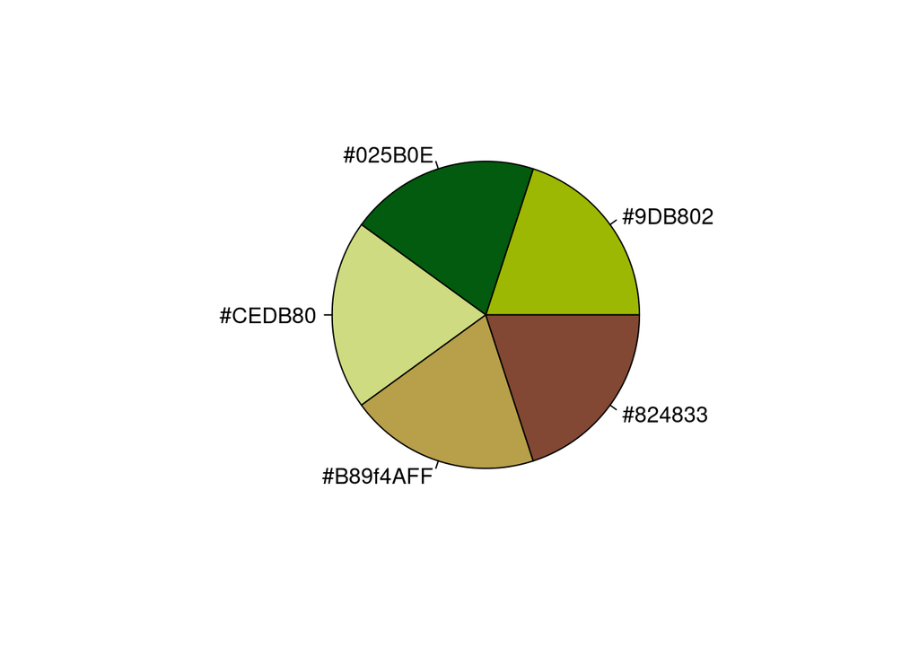

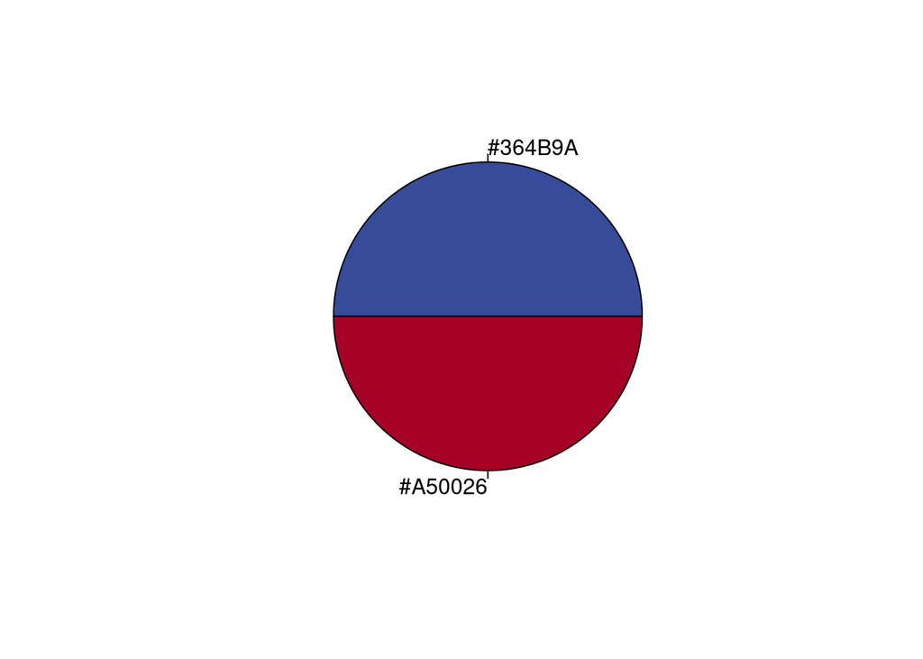

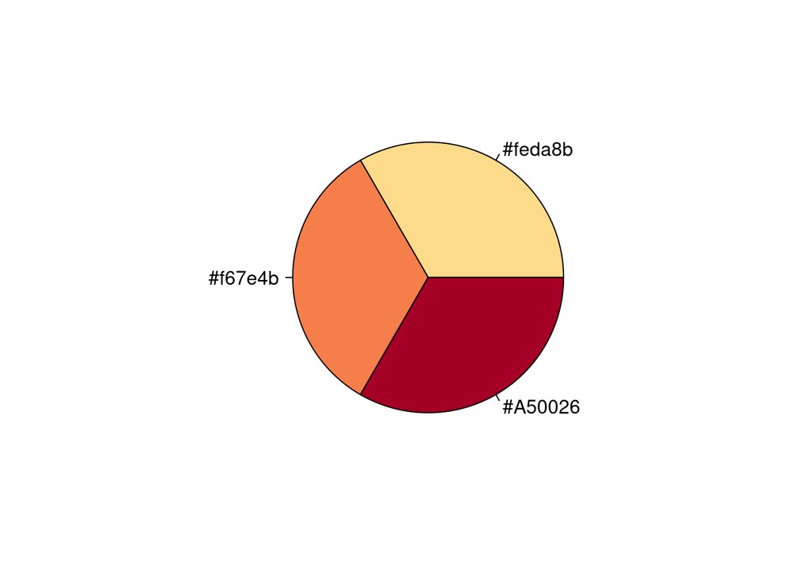

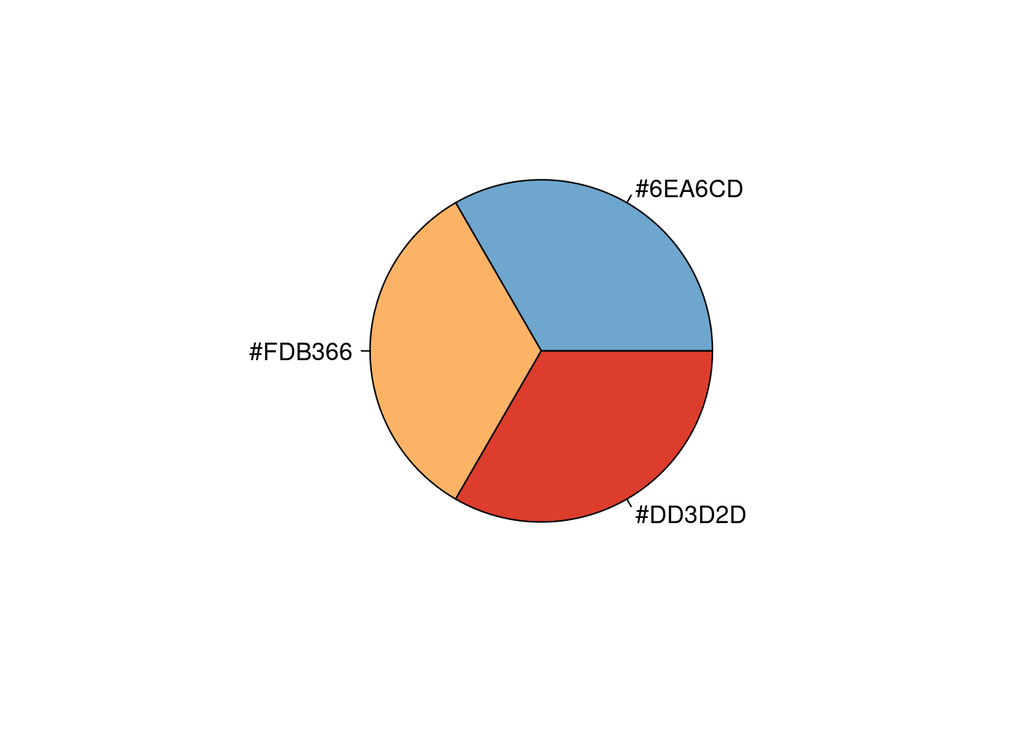

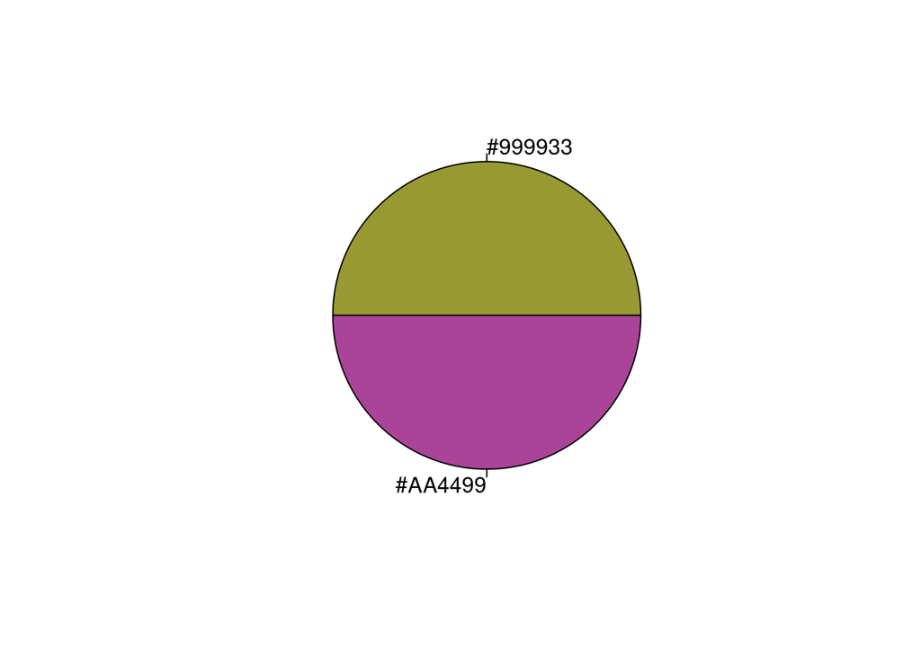

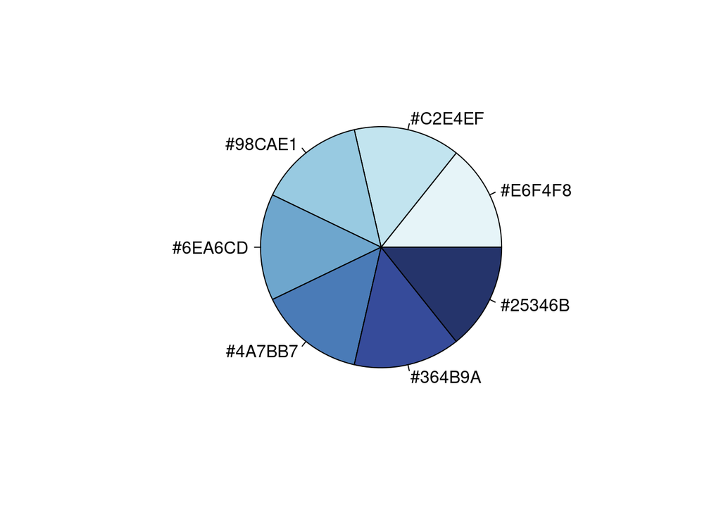

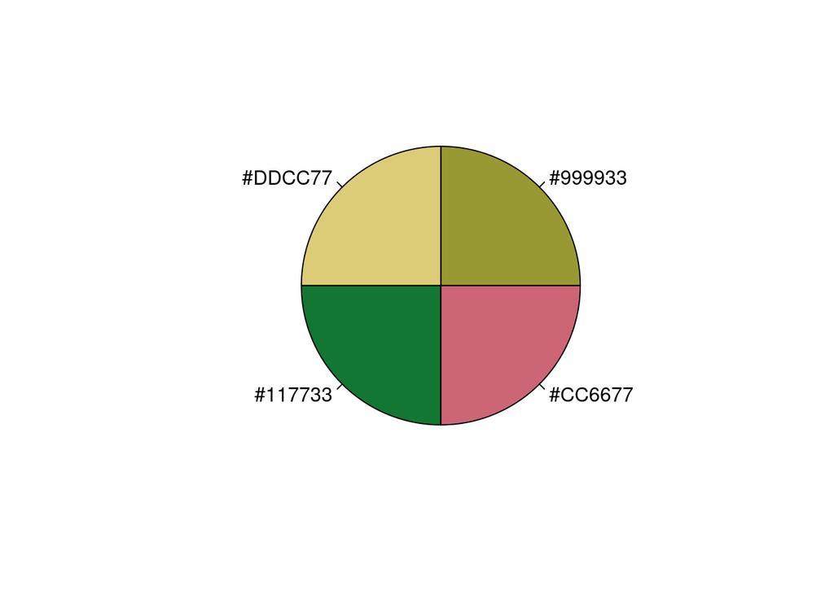

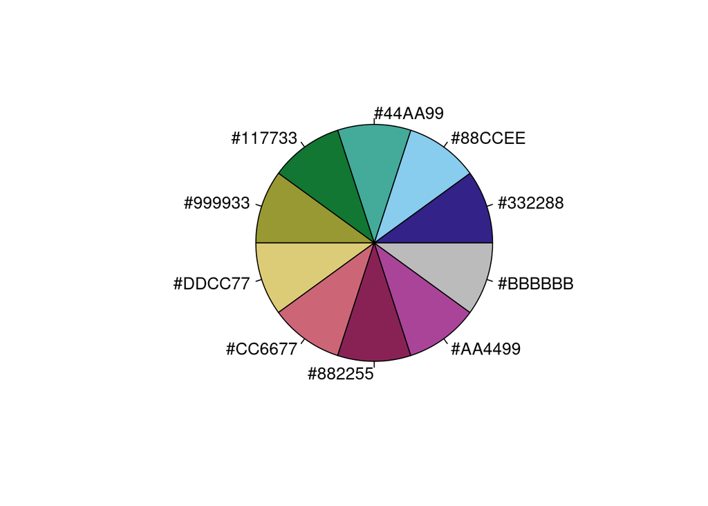

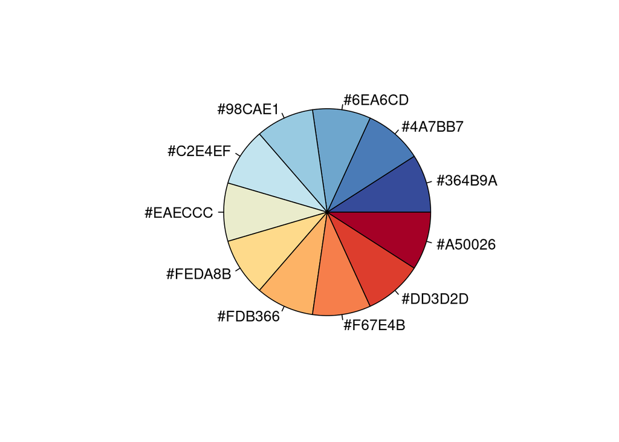

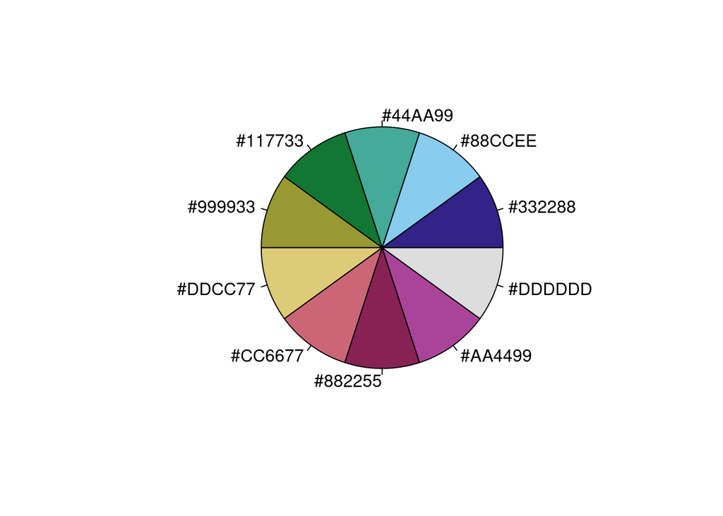

```r
yes_no_pal <- c("Yes"="#B2DF8A", "No"="#FB9A99" , "Maybe"="#A6CEE3")
true_false_pal <- c("TRUE"="#B2DF8A", "FALSE"="#FB9A99" )
t_cells_size <- c("Unusually small"="#33A02C", "Unusually large"="#E31A1C" , "Medium"="#1F78B4", "NA_T_cells_size"= "#CCCCCC")
nc_ratio_pal <- c("Unusually low"="#33A02C", "Unusually high"="#E31A1C" , "Medium"="#1F78B4", "NA_NC_ratio"= "#CCCCCC")
#"#A6CEE3" "#1F78B4" "#B2DF8A" "#33A02C" "#FB9A99" "#E31A1C" "#FDBF6F" "#FF7F00" "#CAB2D6" "#6A3D9A" "#FFFF99" "#B15928"
```

## import data

We import the list of tiles, their annotation (global and tile-by-tile) and their molecular group assignments, and format the data for downstream analyses:

```r
Gannot.pre = read_xlsx("../../Data/Supplementary_Table_S41.xlsx",skip=1) %>% mutate(partition=as.numeric(str_extract(partition_id,"[0-9]+$"))) #globally annotated partitions (i.e., all tiles are very similar)

## internal code to prepare the data, not needed for running the script ##
#load("/data/lungNENomics/work/Descriptive_manuscript_data/Images/Deep_learning_Alexandra/Supervised_Molecular_groups/partition_df_filter2.RData") # list of all tiles in the global partitions
#Gextracted_tiles = read_csv("/data/lungNENomics/work/MathianE/LNEN_LCNEC_Molecular_barlow_twin/leinden_highest_attn_bt_proj/FiguresOverviewPerfRoformerLeiden_K250_res2_run3/TilesExtractionRandom50Tiles/ExtractedTiles.csv") # list of tiles actually reviewed by pathologists
#Gextracted_tiles$TilesExtracted[which( !Gextracted_tiles$TilesExtracted %in% partition_df_filter2$img_id_c )] # check that they are all here
#partition_df_filter2 = partition_df_filter2 %>% dplyr::select(partition,img_id_c,manuscript_id,TNEID,archtype_label_combined,attn_scores_ch0,attn_scores_ch1,attn_scores_ch2) %>% filter(img_id_c %in% Gextracted_tiles$TilesExtracted)
#partition_df_filter2 = partition_df_filter2 %>% filter(partition %in% unique(Gannot.pre$partition))
#write_tsv( partition_df_filter2  , file = "../../Data/Deep_learning_global_partition_tiles.tsv" ) # write results in table
####
load("/data/lungNENomics/work/Descriptive_manuscript_data/Images/Deep_learning_Alexandra/Supervised_Molecular_groups/partition_df_filter2.RData")

partition_df_filter = read_tsv(  file = "../../Data/Deep_learning_global_partition_tiles.tsv" )
# we join the two
Gannot = left_join(partition_df_filter ,Gannot.pre,by=c("partition")) %>%
  dplyr::rename("patient_id"=TNEID, "erythrocyte"=erythrocytes , "endothelial cell"="endothelial cells" ,
                "ciliated cell"="ciliated cells", "cartilage / chondrocyte"="cartilage", "goblet cell"="gobelet cells",
                "spindle"="spindle cells","pyknotic"= "pyknotic cells","plasmocytoid"="plasmocytoid cells","polygonal"="polygonal cells",
                "macrophage"="macrophages","lymphocyte"=lymphocytes,
                "n:c ratio"="NC ratio","necrosis"="foci of necrosis","tissue architecture"="tissue architecture corrected","tumour cells size"="tumor cells size","reader"="group")

TBTannot = read_xlsx("../../Data/Supplementary_Table_S42.xlsx",skip=1)

## internal code to prepare data
#IDmatch = read_csv("/data/lungNENomics/work/MathianE/LNEN_LCNEC_Molecular_barlow_twin/KEY_FILE_tneid_manuscript_id_match.csv")
#all( TBTannot$patient_id %in% IDmatch$TNEID ) # check that all samples are here
#write_tsv( IDmatch %>% filter(TNEID %in% TBTannot$patient_id ) %>% dplyr::select(TNEID,manuscript_id,archtype_label_combined), file =  "../../Data/Deep_learning_TNEID_sample_id_match.tsv")

IDmatch = read_tsv("../../Data/Deep_learning_TNEID_sample_id_match.tsv")
TBTannot2 = left_join(TBTannot,IDmatch,by=c(patient_id="TNEID"))

# format TBT annotation table to match Global annotation table
colnames(TBTannot2) = tolower(colnames(TBTannot2)) #str_replace_all(,pattern = " ", replacement = "_")
colnames(TBTannot2)[!colnames(TBTannot2) %in% colnames(Gannot)] # only reader and img file name info missing from global annot, ok
```

```
## [1] "imgfname"
```

```r
colnames(Gannot)[!colnames(Gannot) %in% colnames(TBTannot2)] #only image ID (slightly different from img file name), partition ID (not needed with partition number), attention scores, group (similar to reader), and collagen fibers (not in TBT annotations)
```

```
## [1] "img_id_c"        "attn_scores_ch0" "attn_scores_ch1" "attn_scores_ch2"
## [5] "partition_id"    "collagen fibers"
```

```r
# merge the 2 tables
all_annot = bind_rows(TBTannot2,Gannot)

# check archetype annotation
metadata = read_xlsx("../../Data/Supplementary_Table_S1.xlsx",skip=3)

all_annot = left_join(all_annot,metadata,by=c("manuscript_id"="manuscript id"))
```

We format the data and compute statistics for each feature

```r
# format the architecture column
## list possible labels
architecture_labs = unique( unlist( str_split(unique( all_annot$`tissue architecture` ),", ") ) ) # "Trabecular"   "Organoid"     "Nested cells" "Solid"        "NI"           "Rosette"      "Papillary"    "Acinar"       "Follicular"   "No"

## only keep abundant terms
architecture_labs_vals = sapply(architecture_labs, function(x) str_detect(all_annot$`tissue architecture`,x)) #remove Papillary and Follicular with <10 occurences, and No and NI that are the absence of others
architecture_labs_vals = apply(architecture_labs_vals,2,as.character)

all_annot2 = bind_cols(all_annot, architecture_labs_vals[,-c(5,7,9,10)])


all_annot.perTile = all_annot2 %>% pivot_longer( c(fibroblast:necrosis,Trabecular:Acinar) ,names_to = "Feature") %>%
  mutate(value_numeric = case_when(value=="No" ~ 0,
                                   value=="Yes" ~ 1,
                                   value=="Unusually small"~0,
                                   value=="Unusually low"~0,
                                   value=="Medium"~0.5,
                                   value=="Maybe"~0.5,
                                   value=="Unusually high"~1,
                                   value=="Unusually large"~1,
                                   value=="TRUE"~1,
                                   value=="FALSE"~0,
                                   TRUE~NA)) %>%
  group_by(imgfname,Feature) %>% summarize(value_numeric = mean(value_numeric,na.rm=T),group=archtype_label_combined[1],partition=partition[1])
# format other columns to numerical value
all_annot.perSample = all_annot2 %>% pivot_longer( c(fibroblast:necrosis,Trabecular:Acinar) ,names_to = "Feature") %>%
  mutate(value_numeric = case_when(value=="No" ~ 0,
                                   value=="Yes" ~ 1,
                                   value=="Unusually small"~0,
                                   value=="Unusually low"~0,
                                   value=="Medium"~0.5,
                                   value=="Maybe"~0.5,
                                   value=="Unusually high"~1,
                                   value=="Unusually large"~1,
                                   value=="TRUE"~1,
                                   value=="FALSE"~0,
                                   TRUE~NA)) %>%
  group_by(patient_id,Feature) %>% summarize(value_numeric = mean(value_numeric,na.rm=T),group=archtype_label_combined[1])
set.seed(0)
all_annot.perSample.stats = data.frame(Feature=NULL,"Statistic"=NULL,"Parameter"=NULL,"P_value"=NULL)
for(feat in unique(all_annot.perSample$Feature)[-29]){ # without tissue architecture, which is not numeric
  print(feat)
  datatmp = all_annot.perSample %>% filter(Feature==feat)
  res = kruskal.test(value_numeric~group,data=datatmp)
  res.means = datatmp %>% group_by(group) %>% summarize(mean = mean(value_numeric,na.rm=T))

  means.perm=c()
  for(i in 1:10000){
    group.perm = sample(datatmp$group,replace=F)
    means.perm = rbind(means.perm,c( mean(datatmp$value_numeric[group.perm=="Ca A1"],na.rm=T),
                    mean(datatmp$value_numeric[group.perm=="Ca A2"],na.rm=T),
                    mean(datatmp$value_numeric[group.perm=="Ca B"],na.rm=T) ) )
  }
  pval_A1A2 = mean( abs(res.means$mean[1]-res.means$mean[2]) <= abs(means.perm[,1]-means.perm[,2]) )
  pval_A1B  = mean( abs(res.means$mean[1]-res.means$mean[3]) <= abs(means.perm[,1]-means.perm[,3]) )
  pval_A2B  = mean( abs(res.means$mean[2]-res.means$mean[3]) <= abs(means.perm[,2]-means.perm[,3]) )
  pval_global  = mean( (abs(res.means$mean[1]-res.means$mean[2])+abs(res.means$mean[1]-res.means$mean[3]))  <=
          (abs(means.perm[,1]-means.perm[,2]) + abs(means.perm[,1]-means.perm[,3]) ) )

  all_annot.perSample.stats = rbind( all_annot.perSample.stats, c(feat,res$statistic,res$parameter,res$p.value,(res.means %>% arrange( group) )$mean,
                                                                  pval_A1A2,pval_A1B,pval_A2B,pval_global) )
}
```

```
## [1] "Acinar"
## [1] "Nested cells"
## [1] "Organoid"
## [1] "Rosette"
## [1] "Solid"
## [1] "Trabecular"
## [1] "cartilage / chondrocyte"
## [1] "ciliated cell"
## [1] "clear cell changes"
## [1] "conspicuous nucleoli"
## [1] "endothelial cell"
## [1] "erythrocyte"
## [1] "fibroblast"
## [1] "fibrosis"
## [1] "goblet cell"
## [1] "high pleomorphism"
## [1] "lymphocyte"
## [1] "macrophage"
## [1] "n:c ratio"
## [1] "necrosis"
## [1] "oncocytic changes"
## [1] "plasma cells"
## [1] "plasmocytoid"
## [1] "polygonal"
## [1] "pyknotic"
## [1] "round cells"
## [1] "salt and pepper chromatin"
## [1] "spindle"
## [1] "tumour cells size"
```

```r
colnames(all_annot.perSample.stats) = c("Feature","Statistic","Parameter","P_value","Ca A1","Ca A2","Ca B",
                                        "empirical_P_value_A1vsA2","empirical_P_value_A1vsB","empirical_P_value_A2vsB","empirical_P_value_global")
for(j in 2:ncol(all_annot.perSample.stats)) all_annot.perSample.stats[,j] = as.numeric(all_annot.perSample.stats[,j])

all_annot.perSample.stats$q_value = p.adjust(all_annot.perSample.stats$P_value,method = "BH")
all_annot.perSample.stats$empirical_q_value_A1vsA2 = p.adjust(all_annot.perSample.stats$empirical_P_value_A1vsA2,method = "BH")
all_annot.perSample.stats$empirical_q_value_A1vsB  = p.adjust(all_annot.perSample.stats$empirical_P_value_A1vsB,method = "BH")
all_annot.perSample.stats$empirical_q_value_A2vsB  = p.adjust(all_annot.perSample.stats$empirical_P_value_A2vsB,method = "BH")
all_annot.perSample.stats$empirical_q_value_global = p.adjust(all_annot.perSample.stats$empirical_P_value_global,method = "BH")

all_annot.perSample.stats %>% filter(q_value<=0.05 | empirical_q_value_global<=0.05)
```

```
##                      Feature Statistic Parameter      P_value       Ca A1
## 1                     Acinar  4.307033         2 1.160752e-01 0.001043557
## 2               Nested cells 18.893983         2 7.892666e-05 0.144904489
## 3                   Organoid 18.671539         2 8.821181e-05 0.120134551
## 4                      Solid 18.920171         2 7.789993e-05 0.374675176
## 5    cartilage / chondrocyte 12.268237         2 2.167635e-03 0.008195734
## 6         clear cell changes 27.495550         2 1.070082e-06 0.163630323
## 7                   fibrosis 18.346298         2 1.037891e-04 0.271322447
## 8                 macrophage  9.239102         2 9.857219e-03 0.031789929
## 9                  n:c ratio 10.085760         2 6.455132e-03 0.467845414
## 10         oncocytic changes 29.061610         2 4.890481e-07 0.005673286
## 11              plasmocytoid 28.147814         2 7.722890e-07 0.028548243
## 12                  pyknotic 14.614919         2 6.705182e-04 0.080155378
## 13 salt and pepper chromatin 11.602034         2 3.024477e-03 0.474076886
## 14                   spindle 43.380225         2 3.802802e-10 0.359832348
```

[output cut: 65 more lines]

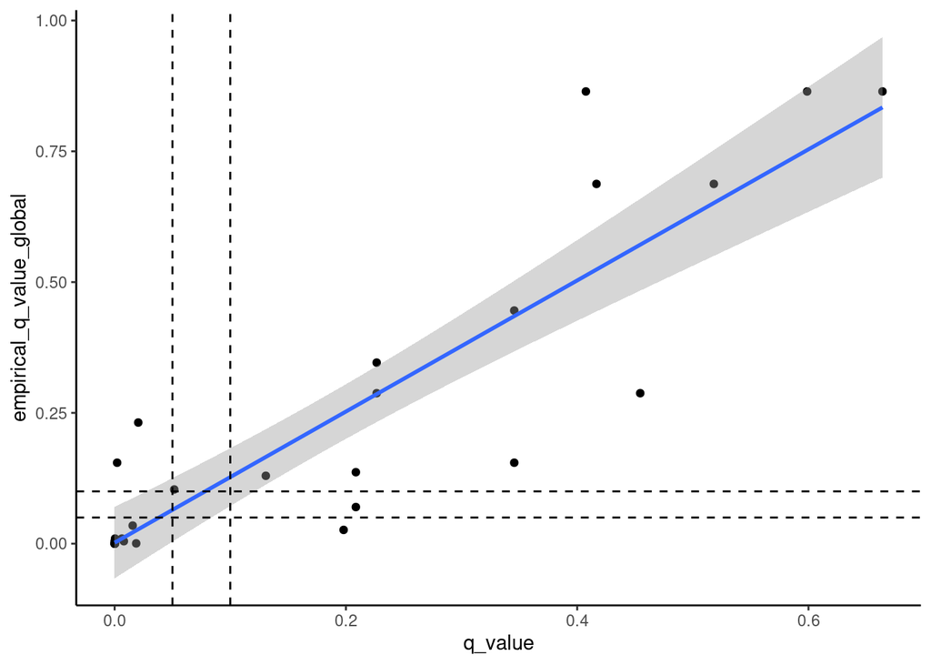

```r
ggplot(all_annot.perSample.stats,aes(x=q_value,y=empirical_q_value_global)) + geom_point() +
  geom_smooth(method = "lm")+ geom_hline(yintercept=c(0.05,0.1),linetype="dashed") +
  geom_vline(xintercept=c(0.05,0.1),linetype="dashed") +
  theme_classic()
```

Write statistical results in a table

```r
write_tsv(all_annot.perSample.stats, "TableS42_stats.tsv")
```

# Fig S17 and 18: morphological features associations with partitions and molecular groups

We plot the results (note that significance codes correspond to Wilcoxon rank sum tests, but we prefer to report the permutation tests computed above in the manuscript)

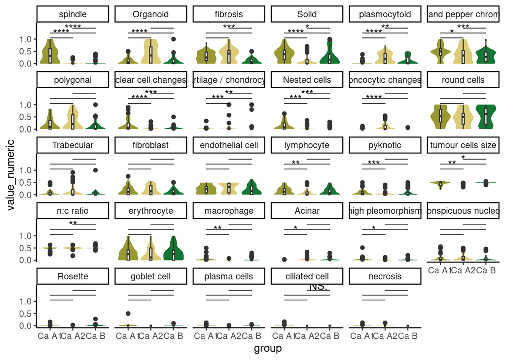

```r
features_list = all_annot.perSample.stats%>% mutate(global_effect_size = abs(`Ca A1`-`Ca A2`)+abs(`Ca A1`-`Ca B`)+abs(`Ca A2`-`Ca B`) ) %>%
  arrange(-global_effect_size) %>% pull(Feature)

all_annot.perSample$Feature = factor(all_annot.perSample$Feature,levels=features_list)

FigS17Lannottests = ggplot(all_annot.perSample %>% filter(!is.na(Feature)),aes(y=value_numeric,x=group,fill=group))+geom_violin(scale = "width",col=NA) + geom_boxplot(width=0.1,fill="white") +
  stat_compare_means(
    comparisons=list(
      c("Ca A1", "Ca A2"),c("Ca A1", "Ca B"),c("Ca A2", "Ca B")),
    method="wilcox.test",
    label="p.signif",
    hide.ns=TRUE,
    tip.length=0,label.y.npc = 0,
    step.increase=0.2,
  ) + scale_y_continuous(limits = c(0,1.6),breaks = c(0,0.5,1.0)) +
  theme_classic() + scale_fill_manual(values=arc4) + facet_wrap(.~Feature) + guides(fill="none")

FigS17Lannottests
```

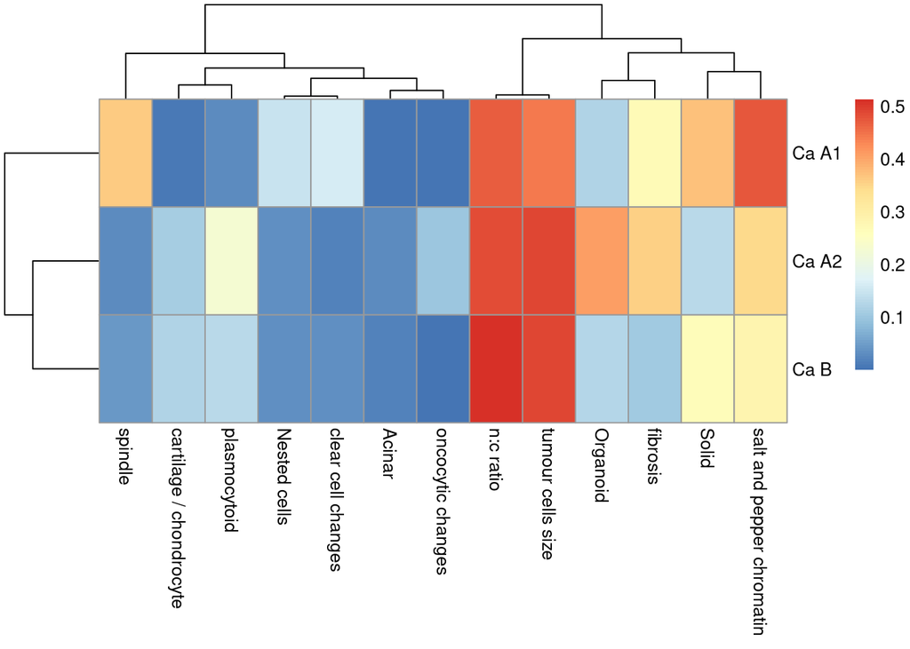

```r
ggsave(FigS17Lannottests,filename="FigS17_annotationtests.svg",h=2*5,w=2*5)
rownames(all_annot.perSample.stats) = all_annot.perSample.stats$Feature
pheatmap::pheatmap( t((all_annot.perSample.stats%>% filter(empirical_q_value_global<=0.05)) [,c(5:7)]) ,scale = "none")
```

We now look for the partitions that drive the signal for each feature

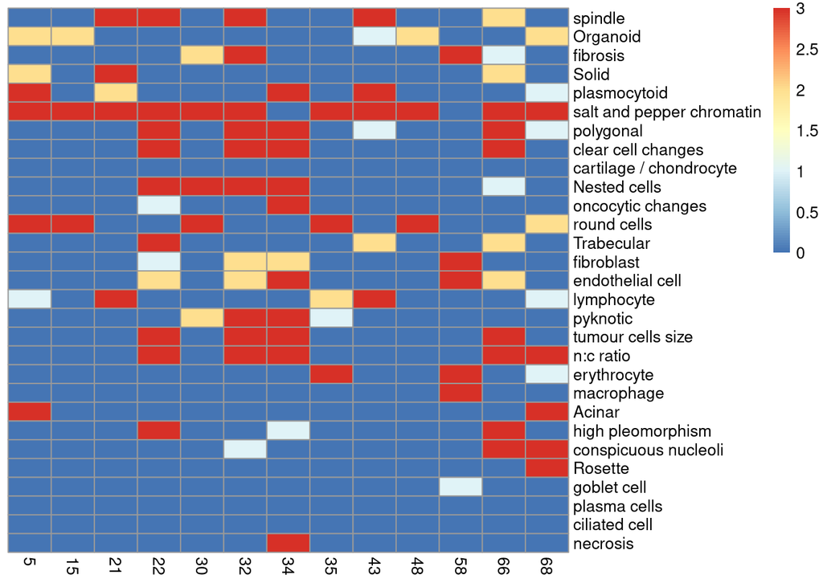

```r
TBTpartition_list = sort( unique(TBTannot$partition) )

all_annot.perTile.wide = all_annot.perTile %>% pivot_wider(values_from=value_numeric,names_from=Feature)

pval_tab = c()
est_tab = c()
gglist = vector("list",length(all_annot.perSample.stats$Feature))
for(i in 1:length(features_list)){ # compute p values
  pval_tab = rbind(pval_tab, sapply( TBTpartition_list , function(j) fisher.test( table(all_annot.perTile.wide[[features_list[i]]][all_annot.perTile.wide$partition %in% TBTpartition_list],
                                                                                        all_annot.perTile.wide$partition[all_annot.perTile.wide$partition %in% TBTpartition_list]==j) )$p.value ) )
  if(!features_list[i] %in% c("tumour cells size","n:c ratio")){
    est_tab = rbind(est_tab, sapply( TBTpartition_list , function(j) fisher.test( table(all_annot.perTile.wide[[features_list[i]]][all_annot.perTile.wide$partition %in% TBTpartition_list] >0,all_annot.perTile.wide$partition[all_annot.perTile.wide$partition %in% TBTpartition_list]==j) )$estimate ) ) # odds ratio estimate for the largest category
  }else{
    est_tab = rbind(est_tab, sapply( TBTpartition_list , function(j) fisher.test( table(all_annot.perTile.wide[[features_list[i]]][all_annot.perTile.wide$partition %in% TBTpartition_list] !=0.5,all_annot.perTile.wide$partition[all_annot.perTile.wide$partition %in% TBTpartition_list]==j) )$estimate ) ) # odds ratio estimate for non medium category
  }

}
rownames(pval_tab) = rownames(est_tab) = features_list
colnames(pval_tab) = colnames(est_tab) = TBTpartition_list

qval_tab = apply(pval_tab,2,p.adjust,method="BH")
pheatmap::pheatmap( (qval_tab<=0.05 & est_tab>1)*1 + (qval_tab<=0.01 & est_tab>1)*1 +(qval_tab<=0.001 & est_tab>1)*1, cluster_rows = F,cluster_cols = F ) # significant AND odds ratio >1
```

[figure not shown]

```r
for(i in 1:length(features_list)){ # compute barplots for each feature
  all_annot2.i = all_annot2 %>% group_by(partition,.data[[features_list[i]]] ) %>% summarize(n=n()) %>%
    mutate(Prop=n/sum(n),annotation=case_when(partition%in%TBTpartition_list~"Tile by tile",
                                              TRUE~"Global") )

  ggi = ggplot(all_annot2.i,aes(x=as.factor(partition),y=Prop,fill=.data[[features_list[i]]] )) + geom_bar(stat="identity",show.legend = F) +
    geom_text(data = tibble(annotation="Tile by tile", qval = qval_tab[i,],partition=colnames(qval_tab),estimate = est_tab[i,] ) %>% mutate(Signif=case_when(qval<=0.001~"***",
                                                                                                                                  qval<=0.01~"**",
                                                                                                                                  qval<=0.05~"*",
                                                                                                                                  qval<=0.1~".",
                                                                                                                                  TRUE~"")) %>% filter(estimate>1),
              aes(x=partition,y=0.9,label=Signif),angle=90 ,inherit.aes = F ) +
    scale_fill_manual(values=c(true_false_pal,t_cells_size,nc_ratio_pal,yes_no_pal)) +
    theme_classic() + facet_grid(.~annotation,scales = "free_x") + theme(axis.title = element_blank(),axis.text.x=element_text(angle=90,hjust = 1,vjust=0.5)) +
    coord_cartesian(expand=F,ylim=c(0,1.07)) + ggtitle(features_list[i])
  gglist[[i]] = ggi
}
patchwork::wrap_plots(gglist, nrow = 6, ncol = 5)
```

```r
ggsave(filename = "FigS17.svg",patchwork::wrap_plots(gglist, nrow = 6, ncol = 5),h=2*6,w=3.5*5)

write.table(est_tab,file = "TableS42_feature_partition_assoc_oddsratio.tsv",sep = "\t")
write.table(pval_tab,file = "TableS42_feature_partition_assoc_pval.tsv",sep = "\t")
write.table(qval_tab,file = "TableS42_feature_partition_assoc_qval.tsv",sep = "\t")
```

We can also plot the features per sample in a heatmap

```r
all_annot.perSample.wide = all_annot.perSample %>% pivot_wider(values_from="value_numeric",names_from =Feature )
hm_data = as.data.frame(all_annot.perSample.wide[,-(1:2)])
rownames(hm_data) = all_annot.perSample.wide$patient_id

hm_row_annot =  all_annot.perSample.wide %>% dplyr::select(group) %>% as.data.frame()
```

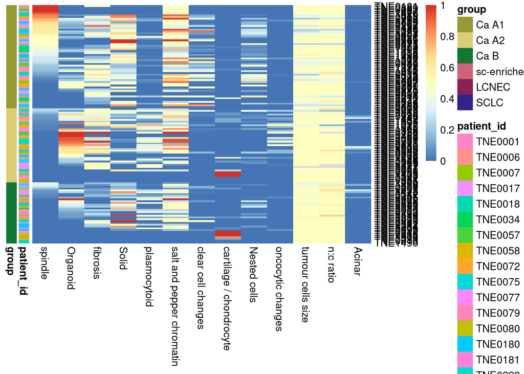

```r
rownames(hm_row_annot) = make.unique(hm_row_annot$patient_id)

# plot
signif_features = all_annot.perSample.stats%>% filter(empirical_q_value_global<=0.05) %>% mutate(global_effect_size = abs(`Ca A1`-`Ca A2`)+abs(`Ca A1`-`Ca B`)+abs(`Ca A2`-`Ca B`) ) %>%
  arrange(-global_effect_size) %>% pull(Feature)  #arrange(empirical_q_value_global) # order by decreasing effect size
sample_order = bind_cols(Sample=rownames(hm_data), Group=all_annot.perSample.wide$group, as_tibble(hm_data)) %>%
  arrange(Group,-`spindle`,-`Organoid`,-`fibrosis`,-`Solid`,-`plasmocytoid`,-`salt and pepper chromatin`,-`clear cell changes`,-`cartilage / chondrocyte`,-`Nested cells`,-`oncocytic changes`,
          -`tumour cells size`,-`n:c ratio`,-`Acinar`) %>% pull(Sample)

pheatmap::pheatmap(hm_data[sample_order,signif_features],cluster_rows = F,cluster_cols = F,scale = "none",annotation_row = hm_row_annot,annotation_colors = list(group=arc4,type=type5) )
```

# Fig. 3d: generalisation of the results with CONCH

We take the cosine similarity results from CONCH for prompts related to spindle shape and fibrosis:

```r
dfQ <- read_tsv("/data/lungNENomics/work/bonhemel/dataset/prompts_quantile_per_slide_Q_0.5_norm_False.tsv")
dfQ_meta <- read_tsv("/data/lungNENomics/work/bonhemel/dataset/TNE_dataset.tsv")
head(dfQ)  # prompts 1--11 are related to spindle shape, 12--21 to fibrosis
```

```
## # A tibble: 6 × 52
##   `cells with spindle shape` `spindle-shaped structures` narrow, elongated cel…¹
##                        <dbl>                       <dbl>                   <dbl>
## 1                     0.171                       0.163                  0.152
## 2                     0.0275                      0.156                  0.114
## 3                    -0.0961                     -0.0205                 0.00433
## 4                    -0.0438                      0.0619                 0.0631
## 5                    -0.105                       0.0233                -0.0502
## 6                     0.0272                      0.0552                 0.0788
## # ℹ abbreviated name: ¹`narrow, elongated cells`
## # ℹ 49 more variables: `narrow, spindle-formed` <dbl>, `spindle shape` <dbl>,
## #   `spindle-like appearance` <dbl>, `spindle arrangement` <dbl>,
## #   `elongated, spindle pattern` <dbl>, `narrow spindle shape` <dbl>,
## #   `spindle cell morphology` <dbl>, `elongated cells` <dbl>,
## #   `fibrosis with collagen-rich fibrous tissue` <dbl>,
## #   `fibrous connective tissue with collagen` <dbl>, …
```

```r
p_list =  list()
pvals_anova = list()
pvals_ttests = list()
for(i in 1:21){
  c_prompt = colnames(dfQ)[i]
  print(c_prompt)
  print(i)
  pQ_norm <- ggplot(data=dfQ, aes(x=archetype_label_combined, y = .data[[c_prompt]] , fill=archetype_label_combined)) +
    geom_violin(col=NA) +  geom_boxplot(fill="white",width=0.1) +
    geom_quasirandom(data=dfQ %>% filter(archetype_label_combined=="sc-enriched"),shape=21, col="white")  +
    scale_fill_manual(values= c(arc4, type5)) +
    stat_compare_means(comparisons = list(
      c("Ca A1","Ca A2"),
      c("Ca A1","Ca B"),
      c("Ca A1","sc-enriched"),
      c("Ca A2","Ca B"),
      c("Ca A2","sc-enriched"),
      c("Ca B","sc-enriched")
    ),
    method = "t.test", label = "p.signif", hide.ns = FALSE, # Show 'ns' for non-significant results
    tip.length = 0) +
    stat_compare_means(method = "anova",label.x = 1, # Adjust to the left-most x position
                       label.y = min(dfQ[[c_prompt]]) ) +
    theme_classic() +
    ylab("Median by WSI") +
    ggtitle(c_prompt) +
    theme(legend.position = "bottom",
          legend.title = element_blank(),
          axis.title.x = element_blank())


  p_list[[i]] <- pQ_norm

  pvals_anova[[i]] <- bind_cols(Prompt=c_prompt,anova( lm(dfQ[[i]]~dfQ$archetype_label_combined) ) %>% broom::tidy() )

  pvals_ttests[[i]] <- bind_cols(Prompt=c_prompt, Level1 = c("Ca A1","Ca A1","Ca A1","Ca A2","Ca A2","Ca B"), Level2 = c("Ca A2","Ca B","sc-enriched","Ca B","sc-enriched","sc-enriched"),
            bind_rows( t.test(dfQ[[i]][dfQ$archetype_label_combined=="Ca A1"],dfQ[[i]][dfQ$archetype_label_combined=="Ca A2"])  %>% broom::tidy(),
  t.test(dfQ[[i]][dfQ$archetype_label_combined=="Ca A1"],dfQ[[i]][dfQ$archetype_label_combined=="Ca B"])  %>% broom::tidy(),
  t.test(dfQ[[i]][dfQ$archetype_label_combined=="Ca A1"],dfQ[[i]][dfQ$archetype_label_combined=="sc-enriched"])  %>% broom::tidy(),
  t.test(dfQ[[i]][dfQ$archetype_label_combined=="Ca A2"],dfQ[[i]][dfQ$archetype_label_combined=="Ca B"])  %>% broom::tidy(),
  t.test(dfQ[[i]][dfQ$archetype_label_combined=="Ca A2"],dfQ[[i]][dfQ$archetype_label_combined=="sc-enriched"])  %>% broom::tidy(),
  t.test(dfQ[[i]][dfQ$archetype_label_combined=="Ca B"],dfQ[[i]][dfQ$archetype_label_combined=="sc-enriched"])  %>% broom::tidy() ) )

}
```

```
## [1] "cells with spindle shape"
## [1] 1
## [1] "spindle-shaped structures"
## [1] 2
## [1] "narrow, elongated cells"
## [1] 3
## [1] "narrow, spindle-formed"
## [1] 4
## [1] "spindle shape"
## [1] 5
## [1] "spindle-like appearance"
## [1] 6
## [1] "spindle arrangement"
## [1] 7
## [1] "elongated, spindle pattern"
```

[output cut: 27 more lines]

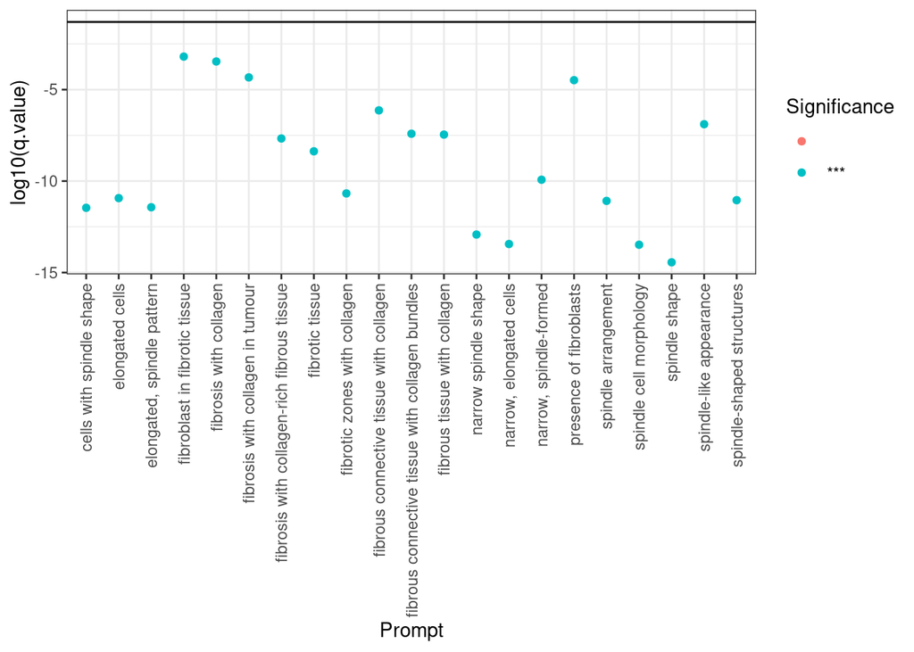

```r
pvals_anova = bind_rows(pvals_anova)
pvals_anova = pvals_anova %>% mutate(q.value = p.adjust(p.value,method = "BH"),
                                     Significance = case_when(q.value<=0.001~"***",
                                                              q.value<=0.01~"**",
                                                              q.value<=0.05~"*",
                                                              q.value<=0.~".",
                                                              TRUE~"") )

ggplot(pvals_anova,aes(x=Prompt,y=log10(q.value),col=Significance )) + geom_point() +
  geom_hline(yintercept = log10(0.05)) + theme_bw() + theme(axis.text.x = element_text(angle=90,hjust = 1,vjust=0.5)) # all significant
```

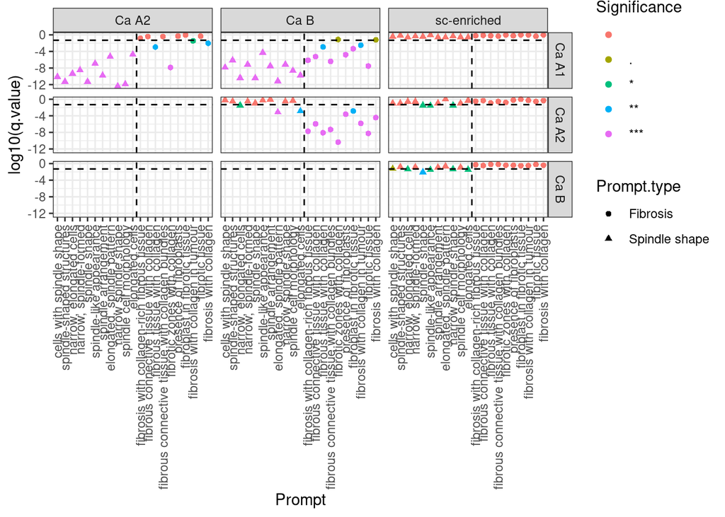

```r
pvals_ttests2 = bind_rows(pvals_ttests) %>% group_by(Level1,Level2) %>% mutate(q.value = p.adjust(p.value,method = "BH"),
                                     Significance = case_when(q.value<=0.001~"***",
                                                              q.value<=0.01~"**",
                                                              q.value<=0.05~"*",
                                                              q.value<=0.1~".",
                                                              TRUE~" ") )

pvals_ttests2$Prompt = factor(pvals_ttests2$Prompt,levels=unique(pvals_ttests2$Prompt))
pvals_ttests2$Prompt.type = case_when(pvals_ttests2$Prompt%in%colnames(dfQ)[1:11]~"Spindle shape",
                                      pvals_ttests2$Prompt%in%colnames(dfQ)[12:21]~"Fibrosis")
pvals_ttests2$Test = paste0(pvals_ttests2$Level1," vs ",pvals_ttests2$Level2)

write_tsv(pvals_anova,file = "TableS42_conch_anova.tsv")
write_tsv(pvals_ttests2,file = "TableS42_conch_ttests.tsv")

ggplot(pvals_ttests2,aes(x=Prompt,y=log10(q.value),col=Significance,shape=Prompt.type )) + geom_point() +
  geom_hline(yintercept = log10(0.05),linetype="dashed") + geom_vline(xintercept = 11.5,linetype="dashed") +
  theme_bw() + theme(axis.text.x = element_text(angle=90,hjust = 1,vjust=0.5)) + facet_grid(Level1~Level2)
```

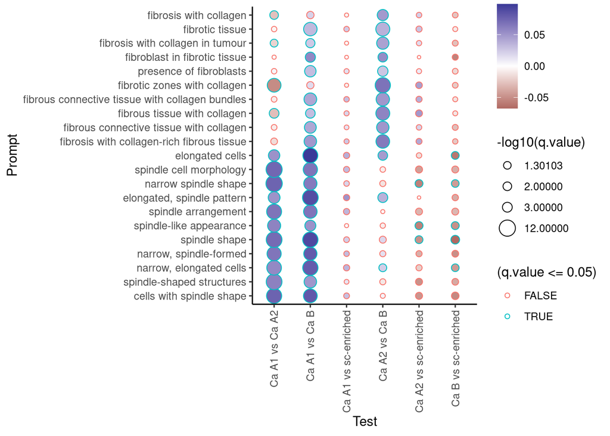

```r
ggpromptsvalcano = ggplot(pvals_ttests2,aes(x=estimate,y=-log10(q.value),col=Prompt.type )) + geom_point() +
  geom_hline(yintercept = -log10(0.05),linetype="dashed") + geom_vline(xintercept = 0,linetype="dashed") +
  ggrepel::geom_text_repel(data = (pvals_ttests2 %>% arrange(abs(q.value)) ) %>% group_by(Test,Prompt.type) %>%
                             mutate(Rank=rank(q.value)) %>% filter(Rank<=3,q.value<=0.05),  # display top 3 significant prompts of each type
                           aes(label = Prompt), size = 3,show.legend = F,force = 2,force_pull = 0.1)  + #pvals_ttests2%>% filter(q.value<=0.05)
  theme_classic() + theme(axis.text.x = element_text(angle=90,hjust = 1,vjust=0.5)) + facet_grid(.~Test) +xlab("Cosine similarity difference") + scale_color_manual(values=c("Fibrosis"="#d35f8dff","Spindle shape"="#2ca05aff"))
#col_signif = c(" "="grey","."="#FFEEAA","*"="#FFCC00","**"="#FF7F2A","***"="#C83737")

ggsave(ggpromptsvalcano,filename="Fig_volcano_prompts.svg",height = 2.5,width=6*2.5)

ggplot( pvals_ttests2 , aes(x=Test,y=Prompt,fill=estimate,size=-log10(q.value),col= (q.value<=0.05) )) + geom_point(shape=21)+
  theme_classic() + theme(axis.text.x = element_text(angle=90,hjust=1,vjust=0.5))+
  scale_size_continuous(breaks=c(0,-log10(0.05),-log10(0.01),-log10(0.001),12)) + scale_fill_gradient2()
```

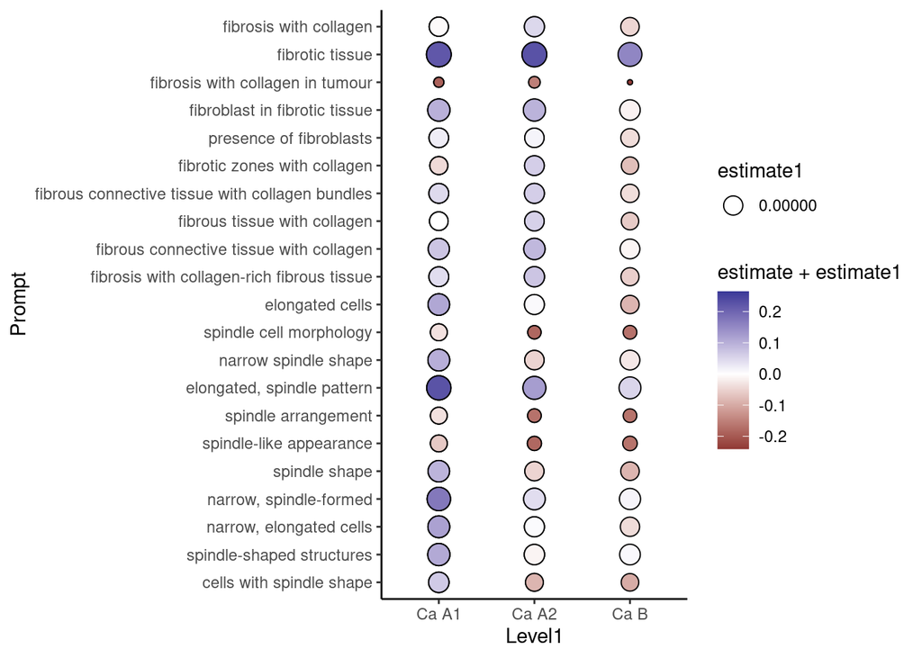

```r
ggplot( pvals_ttests2 , aes(x=Level1,y=Prompt,fill=estimate+estimate1,size=estimate1)) + geom_point(shape=21)+ theme_classic() +
  scale_size_continuous(breaks=c(0,-log10(0.05),-log10(0.01),-log10(0.001),12)) + scale_fill_gradient2()
```

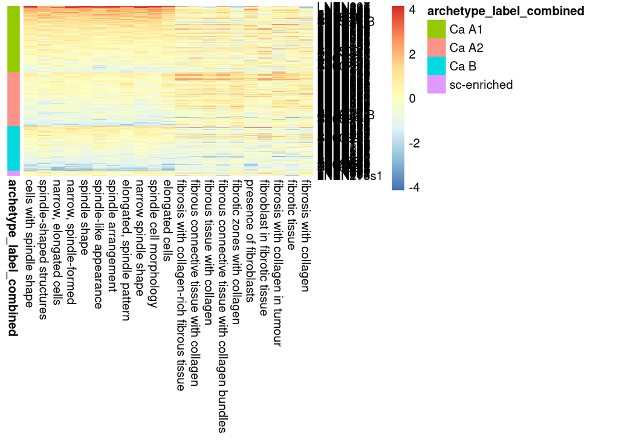

```r
dfQ.df = as.data.frame(dfQ)
rownames(dfQ.df) = dfQ.df$manuscript_id
sample_order = dfQ.df %>% arrange(archetype_label_combined,-rowSums(dfQ.df[,1:11]),-rowSums(dfQ.df[,12:21]) ) %>% pull(manuscript_id)


pheatmap::pheatmap(dfQ.df[sample_order,1:21],scale = "column",cluster_cols = F,cluster_rows = F,annotation_row = dfQ.df %>% dplyr::select(archetype_label_combined))
```

```r
ggsave(p_list[[5]]+p_list[[20]],filename="Fig3d_spindle.svg",height=3,width=2.5*2)

png(paste0("SpindleCells_distribution_median_scores_norm_false.png"), width = 3800, height = 2200, res=300)
ggarrange( p_list[[1]],  p_list[[2]],  p_list[[3]],  p_list[[4]],
           p_list[[5]],  p_list[[6]],  p_list[[7]],  p_list[[8]] ,
           p_list[[9]], p_list[[10]],
           ncol= 4, nrow=2, common.legend = T, legend="bottom")
```

```
## $`1`
```

```
##
## $`2`
```

```
##
## attr(,"class")
## [1] "list"      "ggarrange"
```

```r
dev.off()
```

```r
png(paste0("SpindleCells_distribution_median_scores_norm_false_simplified.png"), width = 2850, height = 2350, res=300)
ggarrange( p_list[[1]],  p_list[[2]],  p_list[[3]],
           p_list[[5]],  p_list[[6]],  p_list[[9]],
           ncol= 3, nrow=2, common.legend = T, legend="bottom")
dev.off()
```

```r
png(paste0("Collagen_distribution_median_scores_norm_false.png"), width = 2850, height = 2350, res=300)
ggarrange( p_list[[12]],  p_list[[13]],  p_list[[14]],
           p_list[[15]],   p_list[[16]],
           common.legend = T, legend="bottom")
dev.off()
```

```r
png(paste0("Fibroblast_distribution_median_scores_norm_false.png"), width = 1900, height = 1175, res=300)
ggarrange(  p_list[[17]],
            p_list[[18]],
            nrow=1,
            common.legend = T, legend="bottom")
dev.off()
```

```r
png(paste0("Fibrosis_distribution_median_scores_norm_false.png"), width = 2850, height = 1175, res=300)
ggarrange(  p_list[[19]],  p_list[[20]],
            p_list[[21]],
            nrow=1,
            common.legend = T, legend="bottom")
dev.off()
```

Compare spindle-cell and marker genes

```r
reg_subtypes = read_xlsx("../../Data/Supplementary_Table_S31.xlsx",skip=1) %>% mutate(manuscript_id = str_remove(`Sample ID`,"_TU[0-9_R]*$"))
```

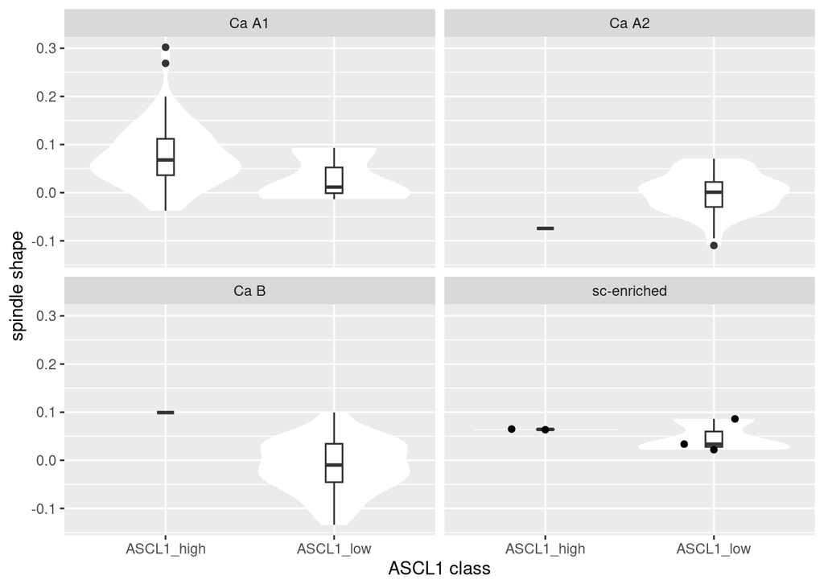

```r
dfQ_regsubtypes = left_join(dfQ,reg_subtypes,by=c("manuscript_id"))

# ASCL1 as category
ggplot(dfQ_regsubtypes %>% filter(!is.na(`ASCL1 class`)), aes(x=`ASCL1 class`,y=`spindle shape`)) +
 geom_violin(col=NA,scale = "width") + geom_boxplot(width=.1) +
  geom_quasirandom(data=dfQ_regsubtypes %>% filter(!is.na(`ASCL1 class`), archetype_label_combined=="sc-enriched"))+
  facet_wrap(.~archetype_label_combined)
```

```r
summary(lm(`spindle shape`~archetype_label_combined+`ASCL1 class`,data=dfQ_regsubtypes)) # differences between groups but not in ASCL1 classes within groups
```

```
##
## Call:
## lm(formula = `spindle shape` ~ archetype_label_combined + `ASCL1 class`,
##     data = dfQ_regsubtypes)
##
## Residuals:
##       Min        1Q    Median        3Q       Max
## -0.124920 -0.034425 -0.004368  0.037610  0.226909
##
## Coefficients:
##                                      Estimate Std. Error t value Pr(>|t|)
## (Intercept)                          0.075256   0.006593  11.415   <2e-16 ***
## archetype_label_combinedCa A2       -0.046044   0.023543  -1.956   0.0521 .
## archetype_label_combinedCa B        -0.053574   0.023740  -2.257   0.0253 *
## archetype_label_combinedsc-enriched -0.002793   0.028729  -0.097   0.9227
## `ASCL1 class`ASCL1_low              -0.030712   0.022695  -1.353   0.1777
## ---
## Signif. codes:  0 '***' 0.001 '**' 0.01 '*' 0.05 '.' 0.1 ' ' 1
##
## Residual standard error: 0.05576 on 174 degrees of freedom
##   (19 observations deleted due to missingness)
## Multiple R-squared:  0.3326, Adjusted R-squared:  0.3172
## F-statistic: 21.68 on 4 and 174 DF,  p-value: 1.581e-14
```

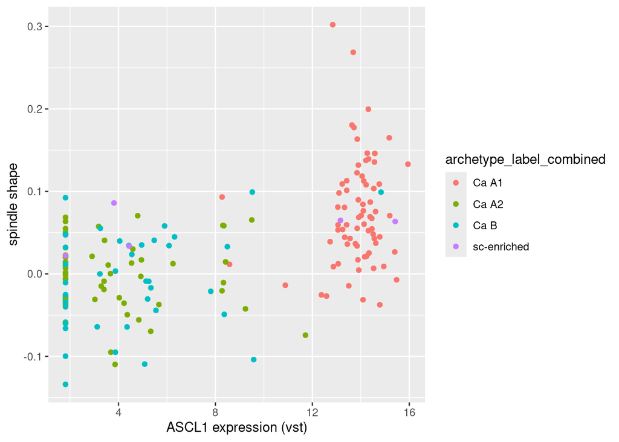

```r
# ASCL1 as continuous variable
ggplot(dfQ_regsubtypes %>% filter(!is.na(`ASCL1 expression (vst)`)), aes(x=`ASCL1 expression (vst)`,y=`spindle shape`,col=archetype_label_combined)) +
 geom_point()
```

```r
summary(lm(`spindle shape`~archetype_label_combined+`ASCL1 expression (vst)`,data=dfQ_regsubtypes)) # differences between groups but not in ASCL1 classes within groups
```

```
##
## Call:
## lm(formula = `spindle shape` ~ archetype_label_combined + `ASCL1 expression (vst)`,
##     data = dfQ_regsubtypes)
##
## Residuals:
##       Min        1Q    Median        3Q       Max
## -0.120033 -0.032600 -0.003172  0.036937  0.230440
##
## Coefficients:
##                                      Estimate Std. Error t value Pr(>|t|)
## (Intercept)                          0.041498   0.025805   1.608  0.10962
## archetype_label_combinedCa A2       -0.051422   0.020611  -2.495  0.01353 *
## archetype_label_combinedCa B        -0.059687   0.020365  -2.931  0.00383 **
## archetype_label_combinedsc-enriched -0.005658   0.028030  -0.202  0.84028
## `ASCL1 expression (vst)`             0.002354   0.001809   1.302  0.19478
## ---
## Signif. codes:  0 '***' 0.001 '**' 0.01 '*' 0.05 '.' 0.1 ' ' 1
##
## Residual standard error: 0.05578 on 174 degrees of freedom
##   (19 observations deleted due to missingness)
## Multiple R-squared:  0.3321, Adjusted R-squared:  0.3167
## F-statistic: 21.63 on 4 and 174 DF,  p-value: 1.689e-14
```

We can check that the EMT score differences reflect spindle shape differences

```r
EMT = read_csv("/data/lungNENomics/work/Descriptive_manuscript_data/RNA_sequencing_data/EMT_score_PCA_LCNEC_SCLC_ITH_TR.csv")
```

```
## ──────────────────────────────────────────────────────── Delimiter: "," chr
## (1): ...1 dbl (3): Epithelial_mean, Mesenchymal_mean, EMT_score
```

```r
EMT = left_join(EMT,metadata,by=c("...1"="sample id")) %>% filter(`LNET k = 4 archetype`%in%c("Ca A1","Ca A2","Ca B","sc-enriched"))

library(ggbeeswarm)

ggEMT = ggplot( EMT , aes(x=`LNET k = 4 archetype`,y=EMT_score,fill=`LNET k = 4 archetype`) ) + geom_violin(col=NA,show.legend = F) + geom_boxplot(width=0.1,fill="white") +
  geom_quasirandom(data=EMT %>% filter(`LNET k = 4 archetype`=="sc-enriched"),col="white",shape=21,show.legend = F) +
  stat_compare_means(
    comparisons=list(
      c("Ca A1", "Ca A2"),c("Ca A1", "Ca B"),c("Ca A1", "sc-enriched"),
      c("Ca A2", "Ca B"),c("Ca A2", "sc-enriched"),c("Ca B", "sc-enriched")),
    method="t.test",
    label="p.signif",
    hide.ns=TRUE,
    tip.length=0,label.y.npc = 0,
    step.increase=0.1,
  ) + scale_fill_manual(values=arc4) + theme_classic()

ggsave(ggEMT,filename="EDFig4B_EMT.svg",height=2.5,width=2.5)
```

# Fig. 3E and Extended Data Fig. 4C: representative examples

Representative examples of spindle cells : in Ca A1 sample, in partition associated with spindle cells, and with both pathologists agreeing on annotation and as little other features as possible

```r
candidates = all_annot.perTile %>% filter(Feature=="spindle",value_numeric==1,group=="Ca A1",partition%in%c(21,22,32,43,66)) %>% pull(imgfname)
TBTannot2 %>% mutate(tot_other = rowSums(TBTannot2[,c(5:15,17:28)]=="Yes"|TBTannot2[,c(5:15,17:28)]=="Medium")) %>% filter(imgfname%in%candidates)  %>% arrange(tot_other)
```

```
## # A tibble: 130 × 31
##    partition patient_id reader imgfname                   fibroblast erythrocyte
##        <dbl> <chr>      <chr>  <chr>                      <chr>      <chr>
##  1        32 TNE0404    r6     TNE0404.svs_47617_52993.j… No         No
##  2        66 TNE1089    r6     TNE1089-HES_39169_24193.j… No         No
##  3        66 TNE1089    r6     TNE1089-HES_23425_30337.j… No         No
##  4        66 TNE1089    r6     TNE1089-HES_18049_19969.j… No         No
##  5        66 TNE1089    r6     TNE1089-HES_10369_25729.j… No         No
##  6        22 TNE1100    r6     TNE1100-HES_57217_30721.j… No         No
##  7        21 TNE1794    r4     TNE1794_59137_18817.jpg    No         No
##  8        21 TNE1428    r4     TNE1428_4225_34561.jpg     No         No
##  9        21 TNE1404    r4     TNE1404-HPS_56449_43777.j… No         No
## 10        21 TNE1404    r4     TNE1404-HPS_55297_29569.j… No         No
## # ℹ 120 more rows
## # ℹ 25 more variables: `endothelial cell` <chr>, `ciliated cell` <chr>,
## #   `cartilage / chondrocyte` <chr>, `goblet cell` <chr>,
## #   `oncocytic changes` <chr>, `conspicuous nucleoli` <chr>,
## #   `high pleomorphism` <chr>, `salt and pepper chromatin` <chr>,
## #   `clear cell changes` <chr>, spindle <chr>, pyknotic <chr>,
## #   `round cells` <chr>, plasmocytoid <chr>, polygonal <chr>, …
```

Representative examples of organoid structure : in Ca A2 sample, in partition associated with organoids, and with both pathologists agreeing on annotation and as little other features as possible

```r
candidates = all_annot.perTile %>% filter(Feature=="Organoid",value_numeric==1,group=="Ca A2",partition%in%c(5,15,43,48,68)) %>% pull(imgfname)
TBTannot2 %>% mutate(tot_other = rowSums(TBTannot2[,c(5:20,22:28)]=="Yes"|TBTannot2[,c(5:20,22:28)]=="Medium")) %>% filter(imgfname%in%candidates,`tissue architecture`=="Organoid")  %>% arrange(tot_other)
```

```
## # A tibble: 9 × 31
##   partition patient_id reader imgfname fibroblast erythrocyte `endothelial cell`
##       <dbl> <chr>      <chr>  <chr>    <chr>      <chr>       <chr>
## 1        48 TNE0965    r1     TNE0965… No         No          No
## 2        48 TNE0965    r1     TNE0965… No         No          Yes
## 3        43 TNE1093    r4     TNE1093… No         No          No
## 4        43 TNE1452    r4     TNE1452… No         Yes         No
## 5         5 TNE0340    r3     TNE0340… No         No          No
## 6        43 TNE1102    r3     TNE1102… Yes        Yes         No
## 7        43 TNE1093    r3     TNE1093… Yes        No          No
## 8        43 TNE1452    r3     TNE1452… Yes        Yes         No
## 9        43 TNE1093    r3     TNE1093… Yes        No          No
## # ℹ 24 more variables: `ciliated cell` <chr>, `cartilage / chondrocyte` <chr>,
## #   `goblet cell` <chr>, `oncocytic changes` <chr>,
## #   `conspicuous nucleoli` <chr>, `high pleomorphism` <chr>,
## #   `salt and pepper chromatin` <chr>, `clear cell changes` <chr>,
## #   spindle <chr>, pyknotic <chr>, `round cells` <chr>, plasmocytoid <chr>,
## #   polygonal <chr>, `tissue architecture` <chr>, macrophage <chr>,
## #   lymphocyte <chr>, `plasma cells` <chr>, `tumour cells size` <chr>, …
```

Representative examples of fibrosis : in Ca A1 or A2 sample, in partition associated with fibrosis, and with both pathologists agreeing on annotation and as little other features as possible

```r
candidates = all_annot.perTile %>% filter(Feature=="fibrosis",value_numeric==1,group%in%c("Ca A1","Ca A2"),partition%in%c(30,32,58,66)) %>% pull(imgfname)
TBTannot2 %>% mutate(tot_other = rowSums(TBTannot2[,c(5:26,28)]=="Yes"|TBTannot2[,c(5:26,28)]=="Medium")) %>% filter(imgfname%in%candidates)  %>% arrange(tot_other)
```

```
## # A tibble: 114 × 31
##    partition patient_id reader imgfname                   fibroblast erythrocyte
##        <dbl> <chr>      <chr>  <chr>                      <chr>      <chr>
##  1        32 TNE1404    r5     TNE1404-HPS_56449_52225.j… No         No
##  2        58 TNE1418    r5     TNE1418_21889_53377.jpg    No         No
##  3        58 TNE1418    r5     TNE1418_5761_31105.jpg     No         No
##  4        58 TNE1416    r5     TNE1416_35713_64513.jpg    No         No
##  5        30 TNE0944    r1     TNE0944.svs_46081_43393.j… No         No
##  6        30 TNE0944    r1     TNE0944.svs_36097_44161.j… No         No
##  7        30 TNE1099    r1     TNE1099-HES_112513_70273.… No         No
##  8        30 TNE1094    r1     TNE1094-HES_26113_6145.jpg No         No
##  9        30 TNE0985    r1     TNE0985-HES_93313_47617.j… No         No
## 10        30 TNE0985    r1     TNE0985-HES_58753_21121.j… Yes        No
## # ℹ 104 more rows
## # ℹ 25 more variables: `endothelial cell` <chr>, `ciliated cell` <chr>,
## #   `cartilage / chondrocyte` <chr>, `goblet cell` <chr>,
## #   `oncocytic changes` <chr>, `conspicuous nucleoli` <chr>,
## #   `high pleomorphism` <chr>, `salt and pepper chromatin` <chr>,
## #   `clear cell changes` <chr>, spindle <chr>, pyknotic <chr>,
## #   `round cells` <chr>, plasmocytoid <chr>, polygonal <chr>, …
```

```r
candidates = all_annot.perTile %>% filter(Feature=="Solid",value_numeric==1,group%in%c("Ca A1","Ca A2"),partition%in%c(5,21,66)) %>% pull(imgfname)
TBTannot2 %>% mutate(tot_other = rowSums(TBTannot2[,c(5:26,28)]=="Yes"|TBTannot2[,c(5:26,28)]=="Medium")) %>% filter(imgfname%in%candidates,`tissue architecture`=="Solid")  %>% arrange(tot_other)
```

```
## # A tibble: 90 × 31
##    partition patient_id reader imgfname                   fibroblast erythrocyte
##        <dbl> <chr>      <chr>  <chr>                      <chr>      <chr>
##  1        21 TNE0072    r4     TNE0072_23041_16897.jpg    No         No
##  2        66 TNE0944    r6     TNE0944.svs_20353_55297.j… No         No
##  3        66 TNE1089    r6     TNE1089-HES_39169_24193.j… No         No
##  4        66 TNE1089    r6     TNE1089-HES_23425_30337.j… No         No
##  5        66 TNE1089    r6     TNE1089-HES_18049_19969.j… No         No
##  6        66 TNE1089    r6     TNE1089-HES_10369_25729.j… No         No
##  7        21 TNE0075    r4     TNE0075_38401_41473.jpg    No         No
##  8        21 TNE1452    r4     TNE1452_97537_43393.jpg    No         No
##  9        21 TNE1428    r4     TNE1428_4225_34561.jpg     No         No
## 10        21 TNE1404    r4     TNE1404-HPS_55297_29569.j… No         No
## # ℹ 80 more rows
## # ℹ 25 more variables: `endothelial cell` <chr>, `ciliated cell` <chr>,
## #   `cartilage / chondrocyte` <chr>, `goblet cell` <chr>,
## #   `oncocytic changes` <chr>, `conspicuous nucleoli` <chr>,
## #   `high pleomorphism` <chr>, `salt and pepper chromatin` <chr>,
## #   `clear cell changes` <chr>, spindle <chr>, pyknotic <chr>,
## #   `round cells` <chr>, plasmocytoid <chr>, polygonal <chr>, …
```

## A good example for Ca A1

```r
partition_df_ssRF = read_tsv("/data/lungNENomics/work/MathianE/LNEN_LCNEC_Molecular_barlow_twin/leinden_random_bt_proj/tile_partitions.tsv")
partition_df_ssRF = partition_df_ssRF %>% mutate(x=as.numeric(str_remove_all(str_extract(img_id_c,"_[0-9]+_"),"_")),
                                                 y=as.numeric(str_remove(str_extract(img_id_c,"_[0-9]+$"),"_")))

partition_df = read_tsv("/data/lungNENomics/work/MathianE/LNEN_LCNEC_Molecular_barlow_twin/leinden_random_bt_proj/tile_partitions.tsv")
A1candidates = all_annot.perSample.wide %>% filter(group=="Ca A1",spindle>0,Organoid==0,fibrosis>0,Solid>0,plasmocytoid==0) %>% arrange(-spindle,-Solid,-fibrosis,Organoid)
A1candidates %>% dplyr::select(patient_id,group,spindle,Solid,fibrosis,Organoid,erythrocyte)
```

```
## # A tibble: 6 × 7
## # Groups:   patient_id [6]
##   patient_id group spindle Solid fibrosis Organoid erythrocyte
##   <chr>      <chr>   <dbl> <dbl>    <dbl>    <dbl>       <dbl>
## 1 TNE0058    Ca A1   0.833 0.833    0.5          0       0.583
## 2 TNE0956    Ca A1   0.611 0.556    0.167        0       0.667
## 3 TNE0404    Ca A1   0.529 0.529    0.471        0       0.412
## 4 TNE1458    Ca A1   0.385 0.231    0.346        0       0.308
## 5 TNE0993    Ca A1   0.286 0.571    0.429        0       0.143
## 6 TNE0416    Ca A1   0.125 0.25     0.5          0       0.75
```

```r
TBTannot2 %>% filter(patient_id %in% A1candidates$patient_id[2])  %>% dplyr::select(patient_id,imgfname,spindle,`tissue architecture`,fibrosis,erythrocyte) %>% filter(`tissue architecture`=="Solid",spindle=="Yes")
```

```
## # A tibble: 6 × 6
##   patient_id imgfname         spindle `tissue architecture` fibrosis erythrocyte
##   <chr>      <chr>            <chr>   <chr>                 <chr>    <chr>
## 1 TNE0956    TNE0956.svs_495… Yes     Solid                 No       No
## 2 TNE0956    TNE0956.svs_487… Yes     Solid                 No       No
## 3 TNE0956    TNE0956.svs_426… Yes     Solid                 Yes      Yes
## 4 TNE0956    TNE0956.svs_403… Yes     Solid                 No       No
## 5 TNE0956    TNE0956.svs_360… Yes     Solid                 No       Yes
## 6 TNE0956    TNE0956.svs_353… Yes     Solid                 No       Yes
```

```r
sort( colSums(A1candidates[1,3:32]) , decreasing=T) # solid, spindle, salt & pepper, erythrocyte, round cells, fibrosis , also probA1 = 0.962 according to RF algo and 0.92 according to RoformerMIL=> good candidate example
```

```
##                     Solid                   spindle salt and pepper chromatin
##                0.83333333                0.83333333                0.75000000
##               erythrocyte               round cells                  fibrosis
##                0.58333333                0.58333333                0.50000000
##                 n:c ratio         tumour cells size          endothelial cell
##                0.45833333                0.37500000                0.33333333
##                fibroblast             ciliated cell        clear cell changes
##                0.33333333                0.16666667                0.16666667
##                  pyknotic      conspicuous nucleoli                 polygonal
##                0.16666667                0.08333333                0.08333333
##                    Acinar              Nested cells                  Organoid
##                0.00000000                0.00000000                0.00000000
##                   Rosette                Trabecular   cartilage / chondrocyte
##                0.00000000                0.00000000                0.00000000
##               goblet cell         high pleomorphism                lymphocyte
##                0.00000000                0.00000000                0.00000000
##                macrophage                  necrosis         oncocytic changes
##                0.00000000                0.00000000                0.00000000
##              plasma cells              plasmocytoid
##                0.00000000                0.00000000
```

```r
sort( colSums(A1candidates[2,3:32]) , decreasing=T) #salt and pepper chromatin, polygonal, erythrocyte, spindle, solid, proba 0.98 according to roformerMIL
```

```
## salt and pepper chromatin                 polygonal               erythrocyte
##                0.94444444                0.83333333                0.66666667
##                   spindle                     Solid      conspicuous nucleoli
##                0.61111111                0.55555556                0.55555556
##                Trabecular               round cells          endothelial cell
##                0.44444444                0.38888889                0.33333333
##              Nested cells                 n:c ratio         tumour cells size
##                0.27777778                0.25000000                0.25000000
##        clear cell changes                  fibrosis                fibroblast
##                0.16666667                0.16666667                0.05555556
##                  pyknotic                    Acinar                  Organoid
##                0.05555556                0.00000000                0.00000000
##                   Rosette   cartilage / chondrocyte             ciliated cell
##                0.00000000                0.00000000                0.00000000
##               goblet cell         high pleomorphism                lymphocyte
##                0.00000000                0.00000000                0.00000000
##                macrophage                  necrosis         oncocytic changes
##                0.00000000                0.00000000                0.00000000
##              plasma cells              plasmocytoid
##                0.00000000                0.00000000
```

```r
sort( colSums(A1candidates[3,3:32]) , decreasing=T)
```

```
##                     Solid                   spindle                  fibrosis
##                0.52941176                0.52941176                0.47058824
##                 n:c ratio               erythrocyte salt and pepper chromatin
##                0.47058824                0.41176471                0.41176471
##         tumour cells size              Nested cells                fibroblast
##                0.38235294                0.23529412                0.23529412
##          endothelial cell      conspicuous nucleoli         high pleomorphism
##                0.20588235                0.11764706                0.11764706
##                 polygonal                  pyknotic        clear cell changes
##                0.11764706                0.11764706                0.05882353
##                lymphocyte               round cells                    Acinar
##                0.05882353                0.05882353                0.00000000
##                  Organoid                   Rosette                Trabecular
##                0.00000000                0.00000000                0.00000000
##   cartilage / chondrocyte             ciliated cell               goblet cell
##                0.00000000                0.00000000                0.00000000
##                macrophage                  necrosis         oncocytic changes
##                0.00000000                0.00000000                0.00000000
##              plasma cells              plasmocytoid                        NA
##                0.00000000                0.00000000                0.00000000
```

```r
sort( colSums(A1candidates[4,3:32]) , decreasing=T)
```

```
##                 n:c ratio               round cells         tumour cells size
##                0.50000000                0.50000000                0.50000000
##                   spindle                  fibrosis salt and pepper chromatin
##                0.38461538                0.34615385                0.34615385
##               erythrocyte          endothelial cell                fibroblast
##                0.30769231                0.26923077                0.26923077
##                     Solid                lymphocyte              Nested cells
##                0.23076923                0.23076923                0.07692308
##             ciliated cell                  pyknotic                    Acinar
##                0.07692308                0.07692308                0.00000000
##                  Organoid                   Rosette                Trabecular
##                0.00000000                0.00000000                0.00000000
##   cartilage / chondrocyte        clear cell changes      conspicuous nucleoli
##                0.00000000                0.00000000                0.00000000
##               goblet cell         high pleomorphism                macrophage
##                0.00000000                0.00000000                0.00000000
##                  necrosis         oncocytic changes              plasma cells
##                0.00000000                0.00000000                0.00000000
##              plasmocytoid                 polygonal
##                0.00000000                0.00000000
```

```r
sort( colSums(A1candidates[5,3:32]) , decreasing=T)
```

```
## salt and pepper chromatin                 polygonal                     Solid
##                 0.8571429                 0.7142857                 0.5714286
##        clear cell changes               round cells                  fibrosis
##                 0.5714286                 0.5714286                 0.4285714
##                 n:c ratio         tumour cells size                fibroblast
##                 0.3571429                 0.3571429                 0.2857143
##                lymphocyte                   spindle                Trabecular
##                 0.2857143                 0.2857143                 0.1428571
##          endothelial cell               erythrocyte                  pyknotic
##                 0.1428571                 0.1428571                 0.1428571
##                    Acinar              Nested cells                  Organoid
##                 0.0000000                 0.0000000                 0.0000000
##                   Rosette   cartilage / chondrocyte             ciliated cell
##                 0.0000000                 0.0000000                 0.0000000
##      conspicuous nucleoli               goblet cell         high pleomorphism
##                 0.0000000                 0.0000000                 0.0000000
##                macrophage                  necrosis         oncocytic changes
##                 0.0000000                 0.0000000                 0.0000000
##              plasma cells              plasmocytoid                        NA
##                 0.0000000                 0.0000000                 0.0000000
```

```r
sort( colSums(A1candidates[6,3:32]) , decreasing=T)
```

```
##               erythrocyte                 n:c ratio                fibroblast
##                     0.750                     0.625                     0.500
##                  fibrosis         tumour cells size                     Solid
##                     0.500                     0.375                     0.250
##          endothelial cell              plasma cells                  pyknotic
##                     0.250                     0.125                     0.125
##               round cells                   spindle                    Acinar
##                     0.125                     0.125                     0.000
##              Nested cells                  Organoid                   Rosette
##                     0.000                     0.000                     0.000
##                Trabecular   cartilage / chondrocyte             ciliated cell
##                     0.000                     0.000                     0.000
##        clear cell changes      conspicuous nucleoli               goblet cell
##                     0.000                     0.000                     0.000
##         high pleomorphism                lymphocyte                macrophage
##                     0.000                     0.000                     0.000
##                  necrosis         oncocytic changes              plasmocytoid
##                     0.000                     0.000                     0.000
##                 polygonal salt and pepper chromatin
##                     0.000                     0.000
```

```r
partition_df_filter2.partprops = partition_df_filter2 %>% group_by(archtype_label_combined,sample_id,partition) %>% summarize(n=n()) %>% mutate(prop=n/sum(n)) %>% ungroup()
```

```
## can override using the `.groups` argument.
```

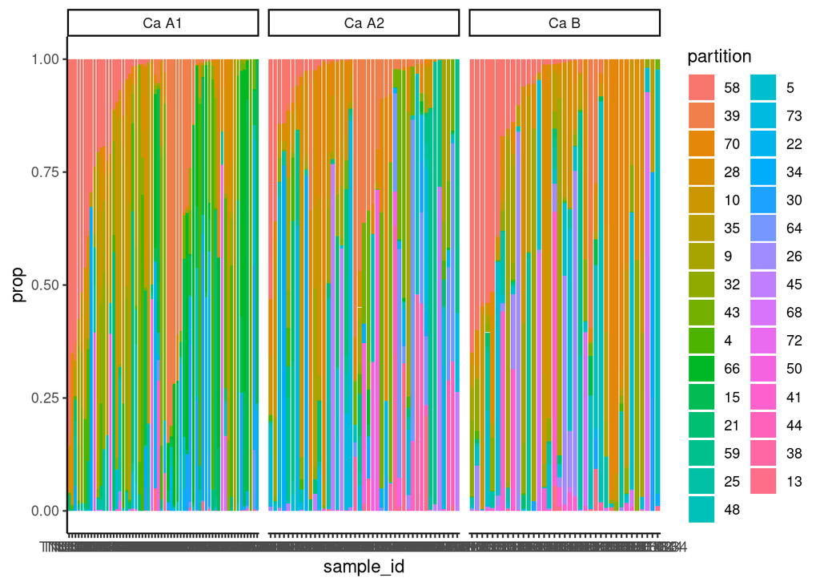

```r
partitionorder = partition_df_filter2.partprops %>% group_by(partition) %>% summarize(meanprop=sum(prop)/140) %>% arrange(-meanprop) %>% pull(partition) %>% unique()
partition_df_filter2.partprops$partition = factor(partition_df_filter2.partprops$partition,levels=partitionorder)

sampleorder = partition_df_filter2.partprops %>% arrange(partition,-prop) %>% pull(sample_id) %>% unique()
partition_df_filter2.partprops$sample_id = factor(partition_df_filter2.partprops$sample_id,levels=sampleorder)

ggplot(partition_df_filter2.partprops,aes(x=sample_id,y=prop,fill=partition )) + geom_bar(stat="identity") + facet_wrap(.~archtype_label_combined,scales = "free_x") + theme_classic() + theme(axis.text.x=element_text())
```

```r
# find most discriminative partitions
partition_df_filter2.partprops.wide = partition_df_filter2.partprops %>% pivot_wider(values_from=prop,names_from=partition,names_prefix = "partition")
partition_df_filter2.partprops.wide[is.na(partition_df_filter2.partprops.wide)] = 0

library(lmPerm)
pvals_assoc_group_partitions = lapply(1:(ncol(partition_df_filter2.partprops.wide)-3),
                                      function(i) bind_cols( colnames(partition_df_filter2.partprops.wide)[i+3], anova(lm(partition_df_filter2.partprops.wide[[i+3]]~partition_df_filter2.partprops.wide$archtype_label_combined ) ) %>%
                                                               broom::tidy())  )
```

```r
pvals_assoc_group_partitions = bind_rows(pvals_assoc_group_partitions)
pvals_assoc_group_partitions$q.value = p.adjust(pvals_assoc_group_partitions$p.value,method="BH")
signifparts_groups = pvals_assoc_group_partitions %>% filter(q.value<=0.05) %>% mutate(partition=str_remove(`...1`,"partition")) #partitions 4, 5,

# dotplot
partition_df_filter2.partprops4dotplot = partition_df_filter2.partprops %>% group_by(archtype_label_combined,partition) %>% summarize(presence=sum(prop>=0.05)/140,abundance=mean(prop[prop>=0.05]))
Fig_dots_partitions = ggplot(partition_df_filter2.partprops4dotplot %>% filter(partition %in% signifparts_groups$partition),aes(x=archtype_label_combined,y=partition,col=abundance,size=presence )) +
  geom_point()+ theme_classic() + theme(axis.text.x=element_text()) + scale_color_viridis_b()

ggsave(Fig_dots_partitions,filename="Fig_dotspartitions.svg",height=2*2,width=3)
```

Partitions associated with A2

```r
A2candidates = all_annot.perSample.wide %>% filter(group=="Ca A2",spindle==0,Organoid>0,fibrosis>0,Solid==0,polygonal>0) %>% arrange(-Organoid,-fibrosis,-polygonal)
A2candidates %>% dplyr::select(patient_id,group,Organoid,fibrosis,polygonal,plasmocytoid) #TNE1430
```

```
## # A tibble: 6 × 6
## # Groups:   patient_id [6]
##   patient_id group Organoid fibrosis polygonal plasmocytoid
##   <chr>      <chr>    <dbl>    <dbl>     <dbl>        <dbl>
## 1 TNE1430    Ca A2   1         1        1            0.5
## 2 TNE0809    Ca A2   0.929     0.643    0.643        0.321
## 3 TNE0228    Ca A2   0.857     0.214    0.143        0.143
## 4 TNE0230    Ca A2   0.8       0.8      0.8          0.4
## 5 TNE1499    Ca A2   0.286     0.429    0.143        0.0714
## 6 TNE1427    Ca A2   0.0556    0.528    0.0556       0.5
```

```r
sort( colSums(A2candidates[1,3:32]) , decreasing=T)#
```

```
##                  Organoid                  fibrosis                 polygonal
##                       1.0                       1.0                       1.0
## salt and pepper chromatin      conspicuous nucleoli          endothelial cell
##                       1.0                       0.5                       0.5
##                fibroblast         oncocytic changes              plasmocytoid
##                       0.5                       0.5                       0.5
##         tumour cells size                    Acinar              Nested cells
##                       0.5                       0.0                       0.0
##                   Rosette                     Solid                Trabecular
##                       0.0                       0.0                       0.0
##   cartilage / chondrocyte             ciliated cell        clear cell changes
##                       0.0                       0.0                       0.0
##               erythrocyte               goblet cell         high pleomorphism
##                       0.0                       0.0                       0.0
##                lymphocyte                macrophage                  necrosis
##                       0.0                       0.0                       0.0
##              plasma cells                  pyknotic               round cells
##                       0.0                       0.0                       0.0
##                   spindle
##                       0.0
```

Partitions associated with B

```r
Bcandidates = all_annot.perSample.wide %>% filter(group=="Ca B",spindle==0,Organoid==0,fibrosis==0,Solid>0,polygonal==0,`round cells`>0) %>% arrange(-Solid,-`round cells`)
Bcandidates %>% dplyr::select(patient_id,group,Organoid,fibrosis,polygonal,plasmocytoid) #TNE1430
```

```
## # A tibble: 1 × 6
## # Groups:   patient_id [1]
##   patient_id group Organoid fibrosis polygonal plasmocytoid
##   <chr>      <chr>    <dbl>    <dbl>     <dbl>        <dbl>
## 1 TNE0403    Ca B         0        0         0        0.462
```

```r
sort( colSums(A2candidates[1,3:32]) , decreasing=T)#
```

```
##                  Organoid                  fibrosis                 polygonal
##                       1.0                       1.0                       1.0
## salt and pepper chromatin      conspicuous nucleoli          endothelial cell
##                       1.0                       0.5                       0.5
##                fibroblast         oncocytic changes              plasmocytoid
##                       0.5                       0.5                       0.5
##         tumour cells size                    Acinar              Nested cells
##                       0.5                       0.0                       0.0
##                   Rosette                     Solid                Trabecular
##                       0.0                       0.0                       0.0
##   cartilage / chondrocyte             ciliated cell        clear cell changes
##                       0.0                       0.0                       0.0
##               erythrocyte               goblet cell         high pleomorphism
##                       0.0                       0.0                       0.0
##                lymphocyte                macrophage                  necrosis
##                       0.0                       0.0                       0.0
##              plasma cells                  pyknotic               round cells
##                       0.0                       0.0                       0.0
##                   spindle
##                       0.0
```

Interpretation of partitions

```r
# partitions associated with A1
all_annot.perTile %>% filter(partition==35) %>% group_by(Feature) %>% summarize(meanfeature = mean(value_numeric)) %>% arrange(-meanfeature) #mostly round cells, erythrocytes
```

```
## # A tibble: 30 × 2
##    Feature                   meanfeature
##    <chr>                           <dbl>
##  1 round cells                     0.84
##  2 Solid                           0.57
##  3 erythrocyte                     0.57
##  4 n:c ratio                       0.505
##  5 tumour cells size               0.495
##  6 salt and pepper chromatin       0.49
##  7 lymphocyte                      0.33
##  8 fibrosis                        0.27
##  9 spindle                         0.23
## 10 Organoid                        0.2
## # ℹ 20 more rows
```

```r
# 4 spindle cells
all_annot.perTile %>% filter(partition==66) %>% group_by(Feature) %>% summarize(meanfeature = mean(value_numeric)) %>% arrange(-meanfeature) #mostly salt and peper chromatin, polygonal, solid, spindle cells
```

```
## # A tibble: 30 × 2
##    Feature                   meanfeature
##    <chr>                           <dbl>
##  1 salt and pepper chromatin       0.81
##  2 polygonal                       0.69
##  3 Solid                           0.64
##  4 spindle                         0.42
##  5 clear cell changes              0.4
##  6 erythrocyte                     0.4
##  7 fibrosis                        0.4
##  8 n:c ratio                       0.375
##  9 round cells                     0.36
## 10 conspicuous nucleoli            0.35
## # ℹ 20 more rows
```

```r
all_annot.perTile %>% filter(partition==15) %>% group_by(Feature) %>% summarize(meanfeature = mean(value_numeric)) %>% arrange(-meanfeature) #mostly salt and peper chromatin, round cells, organoid architecture
```

```
## # A tibble: 30 × 2
##    Feature                   meanfeature
##    <chr>                           <dbl>
##  1 salt and pepper chromatin       0.84
##  2 round cells                     0.82
##  3 Solid                           0.54
##  4 tumour cells size               0.515
##  5 n:c ratio                       0.5
##  6 Organoid                        0.33
##  7 fibrosis                        0.2
##  8 endothelial cell                0.18
##  9 spindle                         0.18
## 10 polygonal                       0.17
## # ℹ 20 more rows
```

```r
all_annot.perTile %>% filter(partition==22) %>% group_by(Feature) %>% summarize(meanfeature = mean(value_numeric)) %>% arrange(-meanfeature) #mostly salt and peper chromatin, polygonal, clear cell changes, spindle cells
```

```
## # A tibble: 30 × 2
##    Feature                   meanfeature
##    <chr>                           <dbl>
##  1 salt and pepper chromatin       0.88
##  2 polygonal                       0.74
##  3 clear cell changes              0.61
##  4 spindle                         0.5
##  5 Nested cells                    0.44
##  6 fibrosis                        0.37
##  7 round cells                     0.34
##  8 endothelial cell                0.33
##  9 n:c ratio                       0.325
## 10 Solid                           0.32
## # ℹ 20 more rows
```

```r
# partitions associated with A2
#59 organoid round cells
#73 fibrosis polygonal cells salt and pepper chromatin
#64  polygonal cells salt and pepper chromatin
#45 round cells
#44 round cells organoid

# partitions associated with B
all_annot.perTile %>% filter(partition==5) %>% group_by(Feature) %>% summarize(meanfeature = mean(value_numeric)) %>% arrange(-meanfeature) #round cells, solid
```

```
## # A tibble: 30 × 2
##    Feature                   meanfeature
##    <chr>                           <dbl>
##  1 round cells                      0.92
##  2 Solid                            0.67
##  3 n:c ratio                        0.56
##  4 tumour cells size                0.5
##  5 salt and pepper chromatin        0.48
##  6 plasmocytoid                     0.44
##  7 Organoid                         0.31
##  8 lymphocyte                       0.31
##  9 erythrocyte                      0.27
## 10 conspicuous nucleoli             0.21
## # ℹ 20 more rows
```

```r
#26 round cells
#41 round cells

# other
#global
#72: spindle cells
#28, 39: erythrocytes

all_annot.perTile %>% filter(partition==32) %>% group_by(Feature) %>% summarize(meanfeature = mean(value_numeric)) %>% arrange(-meanfeature) #mostly salt and peper chromatin, fibrosis, polygonal, solid
```

```
## # A tibble: 30 × 2
##    Feature                   meanfeature
##    <chr>                           <dbl>
##  1 salt and pepper chromatin       0.7
##  2 fibrosis                        0.53
##  3 polygonal                       0.53
##  4 Solid                           0.51
##  5 n:c ratio                       0.475
##  6 round cells                     0.44
##  7 spindle                         0.44
##  8 Nested cells                    0.4
##  9 fibroblast                      0.33
## 10 endothelial cell                0.31
## # ℹ 20 more rows
```

```r
all_annot.perTile %>% filter(partition==58) %>% group_by(Feature) %>% summarize(meanfeature = mean(value_numeric)) %>% arrange(-meanfeature) #nothing above 50%, otherwise erythrocytes, endothelial cells, fribrosis
```

```
## # A tibble: 30 × 2
##    Feature           meanfeature
##    <chr>                   <dbl>
##  1 n:c ratio             0.5
##  2 tumour cells size     0.5
##  3 erythrocyte           0.367
##  4 endothelial cell      0.32
##  5 fibrosis              0.313
##  6 fibroblast            0.307
##  7 macrophage            0.227
##  8 lymphocyte            0.193
##  9 goblet cell           0.0133
## 10 ciliated cell         0.00667
## # ℹ 20 more rows
```

Check correspondance between partition IDs pre and post path review

```r
#partition_df = partition_df %>% mutate(x=as.numeric(str_remove_all(str_extract(img_id_c,"_[0-9]+_"),"_")),
#                                                                                   y=as.numeric(str_remove(str_extract(img_id_c,"_[0-9]+$"),"_")))
#partition_df %>% filter(sample_id=="TNE0956") #"TNE0058")

#partition_df <-  read.csv("/data/lungNENomics/work/MathianE/LNEN_LCNEC_Molecular_barlow_twin/leinden_random_bt_proj/LeidenCom/K_250_res_2.0/partitions_3.csv")
#cheche = left_join(partition_df,partition_df_filter2,by=c("img_id", "sample_id") )
#table(cheche$partition.x,cheche$partition.y)

TBTannot2 = TBTannot2 %>% mutate(x=as.numeric(str_remove_all(str_extract(imgfname,"_[0-9]+_"),"_")),
                                 y=as.numeric(str_remove_all(str_extract(imgfname,"_[0-9]+\\.jpg$"),"_|.jpg")))
Gannot2 = Gannot %>% mutate(x=as.numeric(str_remove_all(str_extract(img_id_c,"_[0-9]+_"),"_")),
                            y=as.numeric(str_remove_all(str_extract(img_id_c,"_[0-9]+$"),"_")))

Gannot2_partition_df_join = left_join(Gannot2,partition_df_filter2 %>% dplyr::select(sample_id,img_id_c,partition,TNEID,x,y),by=c("img_id_c","x","y"))

table(Gannot2_partition_df_join$partition.x,Gannot2_partition_df_join$partition.y) # same partition annotation, all good
```

```
##
##       4 13 26 28 38 39 41 44 45 50 59 64 70 72 73
##   4  50  0  0  0  0  0  0  0  0  0  0  0  0  0  0
##   13  0 50  0  0  0  0  0  0  0  0  0  0  0  0  0
##   26  0  0 50  0  0  0  0  0  0  0  0  0  0  0  0
##   28  0  0  0 50  0  0  0  0  0  0  0  0  0  0  0
##   38  0  0  0  0 50  0  0  0  0  0  0  0  0  0  0
##   39  0  0  0  0  0 50  0  0  0  0  0  0  0  0  0
##   41  0  0  0  0  0  0 50  0  0  0  0  0  0  0  0
##   44  0  0  0  0  0  0  0 50  0  0  0  0  0  0  0
##   45  0  0  0  0  0  0  0  0 50  0  0  0  0  0  0
##   50  0  0  0  0  0  0  0  0  0 50  0  0  0  0  0
##   59  0  0  0  0  0  0  0  0  0  0 50  0  0  0  0
##   64  0  0  0  0  0  0  0  0  0  0  0 50  0  0  0
##   70  0  0  0  0  0  0  0  0  0  0  0  0 50  0  0
##   72  0  0  0  0  0  0  0  0  0  0  0  0  0 50  0
##   73  0  0  0  0  0  0  0  0  0  0  0  0  0  0 50
```

Get partition proportions for the A1 samples

```r
for(TNEnum in A1candidates$patient_id){
  print(getwd())
#TNEnum = "TNE0956" #"TNE0058"
partition_df.TNE = partition_df_filter2 %>% filter( sample_id ==TNEnum ) %>% mutate(x=as.numeric(str_remove_all(str_extract(img_id_c,"_[0-9]+_"),"_")),
                                                                                   y=as.numeric(str_remove(str_extract(img_id_c,"_[0-9]+$"),"_")))

TNE_partitions = partition_df_filter2 %>% filter( sample_id ==TNEnum ) %>% group_by(partition) %>% summarize(n=n()) # 50 => solid architecture (maybe plasmocytoid, maybe salt and pepper chromatin, polygonal and round cells); 14 => discarded; 22=> spindle, salt and pepper, polygonal, clear cell changes; 74 => discarded, 106 => discarded

partitionorder = TNE_partitions %>% arrange(-n) %>% pull(partition)
TNE_partitions$partition = factor(TNE_partitions$partition,levels=partitionorder)
colpartitions = c(RColorBrewer::brewer.pal(3,"Paired"),rep("gray",7))
names(colpartitions) = partitionorder

ggpartitionsTNE = ggplot(TNE_partitions,aes(x=1,y=n,fill=factor(partition))) + geom_bar(stat="identity") + scale_fill_manual(values=colpartitions) + theme_classic()


ggsave(ggpartitionsTNE,filename=paste0(TNEnum,"_barplotparts.svg"),height=2.5,width=2.5)
# plot slide
TBTannot2.TNE = TBTannot2 %>% filter(patient_id ==TNEnum) %>% mutate(x=as.numeric(str_remove_all(str_extract(imgfname,"_[0-9]+_"),"_")),
                                                                                   y=as.numeric(str_remove_all(str_extract(imgfname,"_[0-9]+\\.jpg$"),"_|.jpg"))) # get TBT annots => 5 tiles from partition 32 : spindle cells + fibrosis + other things
Gannot2.TNE = Gannot %>% filter(patient_id ==TNEnum) %>% mutate(x=as.numeric(str_remove_all(str_extract(img_id_c,"_[0-9]+_"),"_")),
                                                                                   y=as.numeric(str_remove_all(str_extract(img_id_c,"_[0-9]+$"),"_")))  # get Global annots => 2 tiles from partition 4 : spindle cells + round cells


partition_df.TNE$partition = factor(partition_df.TNE$partition,levels=partitionorder)
ggparts = ggplot(partition_df.TNE , aes(x=x,y=-y,fill=partition)) + geom_tile() +
  geom_point(data = TBTannot2.TNE%>%filter(patient_id=="TNE0956",x%in%c(40321)), aes(x=x,y=-y),col="red",inherit.aes = F) +
  #geom_point(data = TBTannot2.TNE%>%filter(patient_id=="TNE0956",x%in%c(49537)), aes(x=x,y=-y),col="blue",inherit.aes = F) +
  geom_point(data = Gannot2.TNE, aes(x=x,y=-y),col="orange",inherit.aes = F) +
  scale_fill_manual(values=colpartitions) + theme_classic() + coord_fixed(xlim=range(partition_df$x),ylim=c(-1,-96001))
ggsave(ggparts,filename=paste0(TNEnum,".svg"))
ggparts

ggparts_ssRF = ggplot(partition_df_ssRF %>% filter(sample_id=="TNE0956") , aes(x=x,y=-y,fill=factor(partition))) + geom_tile() +
  geom_point(data = TBTannot2.TNE, aes(x=x,y=-y),col="red",inherit.aes = F) +
  geom_point(data = Gannot2.TNE, aes(x=x,y=-y),col="orange",inherit.aes = F) +
  #scale_fill_manual(values=colpartitions) + theme_classic() +
  coord_fixed(xlim=range(partition_df$x),ylim=c(-1,-96001))

print(ggparts + ggparts_ssRF)

ggsave(ggparts_ssRF,filename=paste0(TNEnum,"_ss.svg"))
}
```

[output not shown]

```
## [1] "/data/lungNENomics/work/alcalan/MS_lungNENomics/Figures/Figure3"
```

```
## [1] "/data/lungNENomics/work/alcalan/MS_lungNENomics/Figures/Figure3"
```

```
## [1] "/data/lungNENomics/work/alcalan/MS_lungNENomics/Figures/Figure3"
```

```
## [1] "/data/lungNENomics/work/alcalan/MS_lungNENomics/Figures/Figure3"
```

```
## [1] "/data/lungNENomics/work/alcalan/MS_lungNENomics/Figures/Figure3"
```

```
## [1] "/data/lungNENomics/work/alcalan/MS_lungNENomics/Figures/Figure3"
```

```r
for(TNEnum in A2candidates$patient_id){
  print(getwd())
partition_df.TNE = partition_df_filter2 %>% filter( sample_id ==TNEnum ) %>% mutate(x=as.numeric(str_remove_all(str_extract(img_id_c,"_[0-9]+_"),"_")),
                                                                                   y=as.numeric(str_remove(str_extract(img_id_c,"_[0-9]+$"),"_")))

TNE_partitions = partition_df_filter2 %>% filter( sample_id ==TNEnum ) %>% group_by(partition) %>% summarize(n=n())

partitionorder = TNE_partitions %>% arrange(-n) %>% pull(partition)
TNE_partitions$partition = factor(TNE_partitions$partition,levels=partitionorder)
colpartitions = c(RColorBrewer::brewer.pal(3,"Paired"),rep("gray",length(partitionorder)-3 ))
names(colpartitions) = partitionorder

ggpartitionsTNE = ggplot(TNE_partitions,aes(x=1,y=n,fill=factor(partition))) + geom_bar(stat="identity") + scale_fill_manual(values=colpartitions) + theme_classic()


ggsave(ggpartitionsTNE,filename=paste0(TNEnum,"_barplotparts.svg"),height=2.5,width=2.5)
# plot slide
TBTannot2.TNE = TBTannot2 %>% filter(patient_id ==TNEnum) %>% mutate(x=as.numeric(str_remove_all(str_extract(imgfname,"_[0-9]+_"),"_")),
                                                                                   y=as.numeric(str_remove_all(str_extract(imgfname,"_[0-9]+\\.jpg$"),"_|.jpg"))) # get TBT annots => 5 tiles from partition 32 : spindle cells + fibrosis + other things
Gannot2.TNE = Gannot %>% filter(patient_id ==TNEnum) %>% mutate(x=as.numeric(str_remove_all(str_extract(img_id_c,"_[0-9]+_"),"_")),
                                                                                   y=as.numeric(str_remove_all(str_extract(img_id_c,"_[0-9]+$"),"_")))  # get Global annots => 2 tiles from partition 4 : spindle cells + round cells


partition_df.TNE$partition = factor(partition_df.TNE$partition,levels=partitionorder)
ggparts = ggplot(partition_df.TNE , aes(x=x,y=-y,fill=partition)) + geom_tile() +
  geom_point(data = TBTannot2.TNE%>%filter(patient_id==TNEnum), aes(x=x,y=-y),col="red",inherit.aes = F) +
  #geom_point(data = TBTannot2.TNE%>%filter(patient_id==TNEnum), aes(x=x,y=-y),col="blue",inherit.aes = F) +
  geom_point(data = Gannot2.TNE, aes(x=x,y=-y),col="orange",inherit.aes = F) +
  scale_fill_manual(values=colpartitions) + theme_classic() + coord_fixed(xlim=range(partition_df$x),ylim=c(-1,-96001))
ggsave(ggparts,filename=paste0("CaA2_",TNEnum,".svg"))
ggparts

ggparts_ssRF = ggplot(partition_df_ssRF %>% filter(sample_id==TNEnum) , aes(x=x,y=-y,fill=factor(partition))) + geom_tile() +
  geom_point(data = TBTannot2.TNE, aes(x=x,y=-y),col="red",inherit.aes = F) +
  geom_point(data = Gannot2.TNE, aes(x=x,y=-y),fill="orange",inherit.aes = F) +
  #geom_point(data = Gannot2.TNE[10,], aes(x=x,y=-y),col="black",fill="orange",inherit.aes = F,shape=21) +
  #scale_fill_manual(values=colpartitions) + theme_classic() +
  coord_fixed(xlim=range(partition_df$x),ylim=c(-1,-96001))

print(ggparts + ggparts_ssRF)

ggsave(ggparts_ssRF,filename=paste0("CaA2_",TNEnum,"_ss.svg"))
}
```

[output not shown]

```
## [1] "/data/lungNENomics/work/alcalan/MS_lungNENomics/Figures/Figure3"
```

```
## [1] "/data/lungNENomics/work/alcalan/MS_lungNENomics/Figures/Figure3"
```

```
## [1] "/data/lungNENomics/work/alcalan/MS_lungNENomics/Figures/Figure3"
```

```
## [1] "/data/lungNENomics/work/alcalan/MS_lungNENomics/Figures/Figure3"
```

```
## [1] "/data/lungNENomics/work/alcalan/MS_lungNENomics/Figures/Figure3"
```

```
## [1] "/data/lungNENomics/work/alcalan/MS_lungNENomics/Figures/Figure3"
```

```r
for(TNEnum in Bcandidates$patient_id){
  print(getwd())
partition_df.TNE = partition_df_filter2 %>% filter( sample_id ==TNEnum ) %>% mutate(x=as.numeric(str_remove_all(str_extract(img_id_c,"_[0-9]+_"),"_")),
                                                                                   y=as.numeric(str_remove(str_extract(img_id_c,"_[0-9]+$"),"_")))

TNE_partitions = partition_df_filter2 %>% filter( sample_id ==TNEnum ) %>% group_by(partition) %>% summarize(n=n())

partitionorder = TNE_partitions %>% arrange(-n) %>% pull(partition)
TNE_partitions$partition = factor(TNE_partitions$partition,levels=partitionorder)
colpartitions = c(RColorBrewer::brewer.pal(4,"Paired"),rep("gray",length(partitionorder)-4 ))
names(colpartitions) = partitionorder

ggpartitionsTNE = ggplot(TNE_partitions,aes(x=1,y=n,fill=factor(partition))) + geom_bar(stat="identity") + scale_fill_manual(values=colpartitions) + theme_classic()


ggsave(ggpartitionsTNE,filename=paste0(TNEnum,"_barplotparts.svg"),height=2.5,width=2.5)
# plot slide
TBTannot2.TNE = TBTannot2 %>% filter(patient_id ==TNEnum) %>% mutate(x=as.numeric(str_remove_all(str_extract(imgfname,"_[0-9]+_"),"_")),
                                                                                   y=as.numeric(str_remove_all(str_extract(imgfname,"_[0-9]+\\.jpg$"),"_|.jpg"))) # get TBT annots => 5 tiles from partition 32 :
#TBTannot2.TNE %>% dplyr::select(partition,imgfname,reader,spindle,`round cells`,plasmocytoid,`tissue architecture`,erythrocyte) # round cells, solid, erythrocyte, maybe plasmocytoid

Gannot2.TNE = Gannot %>% filter(patient_id ==TNEnum) %>% mutate(x=as.numeric(str_remove_all(str_extract(img_id_c,"_[0-9]+_"),"_")),
                                                                                   y=as.numeric(str_remove_all(str_extract(img_id_c,"_[0-9]+$"),"_")))  # get Global annots => 2 tiles from partition 4 : spindle cells + round cells


partition_df.TNE$partition = factor(partition_df.TNE$partition,levels=partitionorder)
ggparts = ggplot(partition_df.TNE , aes(x=x,y=-y,fill=partition)) + geom_tile() +
  geom_point(data = TBTannot2.TNE%>%filter(patient_id==TNEnum), aes(x=x,y=-y),col="red",inherit.aes = F) +
  #geom_point(data = TBTannot2.TNE%>%filter(patient_id==TNEnum), aes(x=x,y=-y),col="blue",inherit.aes = F) +
  geom_point(data = Gannot2.TNE, aes(x=x,y=-y),col="orange",inherit.aes = F) +
  scale_fill_manual(values=colpartitions) + theme_classic() + coord_fixed(xlim=range(partition_df$x),ylim=c(-1,-96001))
ggsave(ggparts,filename=paste0("CaB_",TNEnum,".svg"))

ggparts_ssRF = ggplot(partition_df_ssRF %>% filter(sample_id==TNEnum) , aes(x=x,y=-y,fill=factor(partition))) + geom_tile() +
  geom_point(data = TBTannot2.TNE, aes(x=x,y=-y),col="red",inherit.aes = F) +
  geom_point(data = Gannot2.TNE, aes(x=x,y=-y),fill="orange",inherit.aes = F) +
  #geom_point(data = Gannot2.TNE[2,], aes(x=x,y=-y),col="black",fill="orange",inherit.aes = F,shape=21) +  # useful to highlight particular regions
  #scale_fill_manual(values=colpartitions) + theme_classic() +
  coord_fixed(xlim=range(partition_df$x),ylim=c(-1,-96001))

print(ggparts + ggparts_ssRF)

ggsave(ggparts_ssRF,filename=paste0("CaB_",TNEnum,"_ss.svg"))
}
```

[output not shown]

```
## [1] "/data/lungNENomics/work/alcalan/MS_lungNENomics/Figures/Figure3"
```